# Table of Contents

**Useful Links**

- https://numpy.org/devdocs/reference/routines.char.html

## How to import pandas and check the version?

```python
import numpy as np
import pandas as pd
print(pd.__version__)
# print(pd.show_versions(as_json=True)) # ImportError: Can't determine version for Cython
```

```
0.25.0
```

```python
import os
import time

# random state
random_state=100
np.random.seed(random_state)
```

```python
import re
import collections
from collections import Counter
import dateutil # dateutil.parser.parse
import scipy # scipy.signal.argrelmax
import csv # csv.reader(f)
```

```python
from pandas.api.types import CategoricalDtype
np.set_printoptions(precision=3)
pd.set_option('display.max_columns', 100)
pd.set_option('display.max_rows', 100) # None for all the rows
pd.set_option('display.max_colwidth', 200)
```

## How to create a series from a list, numpy array and dict?

Create a pandas series from each of the items below: a list, numpy and a dictionary

```python
import numpy as np
import pandas as pd

mylist = list('abcedfghijklmnopqrstuvwxyz')
myarr = np.arange(26)
mydict = dict(zip(mylist, myarr))

ser1 = pd.Series(mylist)
ser2 = pd.Series(myarr)
ser3 = pd.Series(mydict)

pd.DataFrame({'a':ser1, 'b': ser2, 'c': ser3.to_numpy()}).tail()
```

|  | a | b | c |
| --- | --- | --- | --- |
| 21 | v | 21 | 21 |
| 22 | w | 22 | 22 |
| 23 | x | 23 | 23 |
| 24 | y | 24 | 24 |
| 25 | z | 25 | 25 |

## How to convert the index of a series into a column of a dataframe?

Convert the series ser into a dataframe with its index as another column on the dataframe.

```python
mylist = list('abcedfghijklmnopqrstuvwxyz')
myarr = np.arange(26)
mydict = dict(zip(mylist, myarr))
ser = pd.Series(mydict)
ser.head(2)
```

```
a    0
b    1
dtype: int64
```

```python
ser.reset_index().head(2) # no need .to_frame()
```

|  | index | 0 |
| --- | --- | --- |
| 0 | a | 0 |
| 1 | b | 1 |

## How to combine many series to form a dataframe?

Combine ser1 and ser2 to form a dataframe.

```python
ser1 = pd.Series(list('abcedfghijklmnopqrstuvwxyz'))
ser2 = pd.Series(np.arange(26))
```

```python
df = pd.concat([ser1, ser2],axis=1)
df = pd.DataFrame({'col1': ser1, 'col2': ser2})
df.head(2)
```

|  | col1 | col2 |
| --- | --- | --- |
| 0 | a | 0 |
| 1 | b | 1 |

## How to assign name to the series’ index?

Give a name to the series ser calling it ‘alphabets’.

```python
ser = pd.Series(list('abcedfghijklmnopqrstuvwxyz'))
```

```python
ser.name = 'alphabets'
ser.head(1)
```

```
0    a
Name: alphabets, dtype: object
```

## How to get the items of series A not present in series B?

From ser1 remove items present in ser2.

```python
ser1 = pd.Series([1, 2, 3, 4, 5])
ser2 = pd.Series([4, 5, 6, 7, 8])
```

```python
%%timeit
pd.Series(np.setdiff1d(ser1.to_numpy(), ser2.to_numpy())) # fast
```

```
112 µs ± 3.34 µs per loop (mean ± std. dev. of 7 runs, 10000 loops each)
```

```python
%%timeit
ser1[~ser1.isin(ser2)]
```

```
459 µs ± 29 µs per loop (mean ± std. dev. of 7 runs, 1000 loops each)
```

## How to get the items not common to both series A and series B?

Get all items of ser1 and ser2 not common to both.

```python
ser1 = pd.Series([1, 2, 3, 4, 5])
ser2 = pd.Series([4, 5, 6, 7, 8])
```

```python
pd.Series(np.setxor1d(ser1.to_numpy(), ser2.to_numpy()))
```

```
0    1
1    2
2    3
3    6
4    7
5    8
dtype: int64
```

## How to get the minimum, 25th percentile, median, 75th, and max of a numeric series?

Compute the minimum, 25th percentile, median, 75th, and maximum of ser.

```python
np.random.seed(100)
ser = pd.Series(np.random.normal(10, 5, 25))
ser.describe()
```

```
count    25.000000
mean     10.435437
std       4.253118
min       1.251173
25%       7.709865
50%      10.922593
75%      13.363604
max      18.094908
dtype: float64
```

```python
np.percentile(ser.to_numpy(), [0,25,50,75,100])
```

```
array([ 1.25117263,  7.70986507, 10.92259345, 13.36360403, 18.0949083 ])
```

## How to get frequency counts of unique items of a series?

Calculte the frequency counts of each unique value ser.

```python
np.random.seed(100)
ser = pd.Series(np.take(list('abcdefgh'), np.random.randint(8, size=30)))
ser.head()
```

```
0    a
1    a
2    d
3    h
4    h
dtype: object
```

```python
ser = pd.Series(rng.choice(list('abcdefgh'), 30))
ser.head()
```

```
0    a
1    a
2    d
3    h
4    h
dtype: object
```

```python
%%timeit
ser.value_counts() # slowest, easy, sort values
```

```
774 µs ± 108 µs per loop (mean ± std. dev. of 7 runs, 1000 loops each)
```

```python
%%timeit
u,c = np.unique(ser.to_numpy(), return_counts= True) # 2nd fast, no sorting
np.array([u,c]).T
```

```
27 µs ± 694 ns per loop (mean ± std. dev. of 7 runs, 10000 loops each)
```

```python
u,c = np.unique(ser.to_numpy(), return_counts= True) # 2nd fast, no sorting
pd.Series(c,index=u)
```

```
a    6
b    2
c    7
d    3
e    3
f    2
g    3
h    4
dtype: int64
```

```python
%%timeit
Counter(ser.to_numpy()) # fastest, no sorting
```

```
7.18 µs ± 459 ns per loop (mean ± std. dev. of 7 runs, 100000 loops each)
```

```python
pd.Series(Counter(ser.to_numpy()))
```

```
a    6
d    3
h    4
c    7
g    3
e    3
f    2
b    2
dtype: int64
```

```python
Counter(ser.to_numpy()).most_common()
```

```
[('c', 7),
 ('a', 6),
 ('h', 4),
 ('d', 3),
 ('g', 3),
 ('e', 3),
 ('f', 2),
 ('b', 2)]
```

```python
%%timeit
Counter(ser.to_numpy()).most_common(len(ser))
```

```
10.7 µs ± 851 ns per loop (mean ± std. dev. of 7 runs, 100000 loops each)
```

## How to keep only top 2 most frequent values as it is and replace everything else as ‘Other’?

From ser, keep the top 2 most frequent items as it is and replace everything else as ‘Other’.

```python
np.random.seed(100)
ser = pd.Series(np.random.randint(1, 5, [12]))
ser
```

```
0     1
1     1
2     4
3     4
4     4
5     4
6     1
7     3
8     3
9     1
10    3
11    2
dtype: int64
```

```python
ser.value_counts() # keep 4,1, and make 3,2 other
```

```
4    4
1    4
3    3
2    1
dtype: int64
```

```python
np.random.seed(100)
ser = pd.Series(np.random.randint(1, 5, [12]))
ser.mode()
```

```
0    1
1    4
dtype: int64
```

```python
idx = ser.value_counts().head(2).index
ser[~ser.isin(idx)]
```

```
7     3
8     3
10    3
11    2
dtype: int64
```

```python
ser[~ser.isin(idx)] = 'Other'
ser # 1,4 are same, 2,3 are replaced by other
```

```
0         1
1         1
2         4
3         4
4         4
5         4
6         1
7     Other
8     Other
9         1
10    Other
11    Other
dtype: object
```

```python
np.random.seed(100)
ser = pd.Series(np.random.randint(1, 5, [12]))
ser[~ser.isin(ser.value_counts().index[:2])] = 'Other'
ser
```

```
0         1
1         1
2         4
3         4
4         4
5         4
6         1
7     Other
8     Other
9         1
10    Other
11    Other
dtype: object
```

```python
np.random.seed(100)
ser = pd.Series(np.random.randint(1, 5, [12]))
ser.replace({x:"Other" for x in ser.value_counts()[2:].index})
```

```
0         1
1         1
2         4
3         4
4         4
5         4
6         1
7     Other
8     Other
9         1
10    Other
11    Other
dtype: object
```

```python
%%timeit

np.random.seed(100)
ser = pd.Series(np.random.randint(1, 5, [12]))

idx = ser.value_counts().head(2).index
ser[~ser.isin(idx)] = 'Other'
```

```
1.86 ms ± 187 µs per loop (mean ± std. dev. of 7 runs, 100 loops each)
```

```python
%%timeit
np.random.seed(100)
ser = pd.Series(np.random.randint(1, 5, [12]))

top2 = Counter(ser.values).most_common(2)
idx = [i[0] for i in top2]
ser[~ser.isin(idx)] = 'Other'
```

```
1.33 ms ± 444 µs per loop (mean ± std. dev. of 7 runs, 100 loops each)
```

```python
Counter(ser.values).most_common(2)
```

```
[(1, 4), (4, 4)]
```

## How to bin a numeric series to 10 groups of equal size?

Bin the series ser into 10 equal deciles and replace the values with the bin name.

```python
ser = pd.Series(np.arange(20))
ser
```

```
0      0
1      1
2      2
3      3
4      4
5      5
6      6
7      7
8      8
9      9
10    10
11    11
12    12
13    13
14    14
15    15
16    16
17    17
18    18
19    19
dtype: int64
```

```python
pd.cut(ser,10)
```

```
0     (-0.019, 1.9]
1     (-0.019, 1.9]
2        (1.9, 3.8]
3        (1.9, 3.8]
4        (3.8, 5.7]
5        (3.8, 5.7]
6        (5.7, 7.6]
7        (5.7, 7.6]
8        (7.6, 9.5]
9        (7.6, 9.5]
10      (9.5, 11.4]
11      (9.5, 11.4]
12     (11.4, 13.3]
13     (11.4, 13.3]
14     (13.3, 15.2]
15     (13.3, 15.2]
16     (15.2, 17.1]
17     (15.2, 17.1]
18     (17.1, 19.0]
19     (17.1, 19.0]
dtype: category
Categories (10, interval[float64]): [(-0.019, 1.9] < (1.9, 3.8] < (3.8, 5.7] < (5.7, 7.6] ... (11.4, 13.3] < (13.3, 15.2] < (15.2, 17.1] < (17.1, 19.0]]
```

```python
pd.qcut(ser, q=[0, .10, .20, .3, .4, .5, .6, .7, .8, .9, 1],
        labels=['1st', '2nd', '3rd', '4th', '5th', '6th', '7th', '8th', '9th', '10th']).head()
```

```
0    1st
1    1st
2    2nd
3    2nd
4    3rd
dtype: category
Categories (10, object): [1st < 2nd < 3rd < 4th ... 7th < 8th < 9th < 10th]
```

## How to convert a numpy array to a dataframe of given shape?

Reshape the series ser into a dataframe with 7 rows and 5 columns

```python
np.random.seed(100)
ser = pd.Series(np.random.randint(1, 10, 35))
ser.head()
```

```
0    9
1    9
2    4
3    8
4    8
dtype: int64
```

```python
pd.DataFrame(ser.to_numpy().reshape(7,5))
```

|  | 0 | 1 | 2 | 3 | 4 |
| --- | --- | --- | --- | --- | --- |
| 0 | 9 | 9 | 4 | 8 | 8 |
| 1 | 1 | 5 | 3 | 6 | 3 |
| 2 | 3 | 3 | 2 | 1 | 9 |
| 3 | 5 | 1 | 7 | 3 | 5 |
| 4 | 2 | 6 | 4 | 5 | 5 |
| 5 | 4 | 8 | 2 | 2 | 8 |
| 6 | 8 | 1 | 3 | 4 | 3 |

## How to find the positions of numbers that are multiples of 3 from a series?

Find the positions of numbers that are multiples of 3 from ser.

```python
np.random.seed(100)
ser = pd.Series(np.random.randint(1, 10, 7))
ser
```

```
0    9
1    9
2    4
3    8
4    8
5    1
6    5
dtype: int64
```

```python
%%timeit
ser[ser%3==0].index
```

```
638 µs ± 60.4 µs per loop (mean ± std. dev. of 7 runs, 1000 loops each)
```

```python
%%timeit
np.argwhere(ser.to_numpy()%3==0)
```

```
11 µs ± 647 ns per loop (mean ± std. dev. of 7 runs, 100000 loops each)
```

```python
%%timeit
np.argwhere(ser%3==0)
```

```
361 µs ± 51.9 µs per loop (mean ± std. dev. of 7 runs, 1000 loops each)
```

```python
ser[np.argwhere(ser.to_numpy()%3==0).ravel()]
```

```
0    9
1    9
dtype: int64
```

```python
ser[ser%3==0]
```

```
0    9
1    9
dtype: int64
```

## How to extract items at given positions from a series

```python
ser = pd.Series(list('abcdefghijklmnopqrstuvwxyz'))
pos = [0, 4, 8, 14, 20]
ser.head()
```

```
0    a
1    b
2    c
3    d
4    e
dtype: object
```

```python
ser[pos]
```

```
0     a
4     e
8     i
14    o
20    u
dtype: object
```

## How to stack two series vertically and horizontally ?

Stack ser1 and ser2 vertically and horizontally (to form a dataframe).

```python
ser1 = pd.Series(range(5))
ser2 = pd.Series(list('abcde'))
```

```python
pd.concat([ser1,ser2],axis=1)
```

|  | 0 | 1 |
| --- | --- | --- |
| 0 | 0 | a |
| 1 | 1 | b |
| 2 | 2 | c |
| 3 | 3 | d |
| 4 | 4 | e |

```python
pd.concat([ser1,ser2],axis=0)
```

```
0    0
1    1
2    2
3    3
4    4
0    a
1    b
2    c
3    d
4    e
dtype: object
```

## **How to get the positions of items of series A in another series B?

Get the positions of items of ser2 in ser1 as a list.

```python
ser1 = pd.Series([10, 9, 6, 5, 3, 1, 12, 8, 13])
ser2 = pd.Series([1, 3, 10, 13]) # 1 is at position 5
```

```python
ser1[ser1.isin(ser2)].index
```

```
Int64Index([0, 4, 5, 8], dtype='int64')
```

```python
np.argwhere( ser1.isin(ser2).to_numpy())
```

```
array([[0],
       [4],
       [5],
       [8]])
```

## How to compute the mean squared error on a truth and predicted series?

Compute the mean squared error of truth and pred series.

```python
truth = pd.Series(range(10))
pred = pd.Series(range(10)) + np.random.random(10)
```

```python
%%timeit
((truth.to_numpy()-pred.to_numpy())**2).mean()
```

```
13 µs ± 593 ns per loop (mean ± std. dev. of 7 runs, 100000 loops each)
```

```python
%%timeit
np.mean((truth.to_numpy()-pred.to_numpy())**2)
```

```
13.3 µs ± 144 ns per loop (mean ± std. dev. of 7 runs, 100000 loops each)
```

```python
%%timeit
((truth-pred)**2).mean()
```

```
273 µs ± 5.5 µs per loop (mean ± std. dev. of 7 runs, 1000 loops each)
```

```python
%%timeit
np.mean((truth-pred)**2)
```

```
281 µs ± 4.99 µs per loop (mean ± std. dev. of 7 runs, 1000 loops each)
```

```python
%%timeit
(truth-pred).pow(2).mean()
```

```
305 µs ± 6.91 µs per loop (mean ± std. dev. of 7 runs, 1000 loops each)
```

## How to convert the first character of each element in a series to uppercase?

Change the first character of each word to upper case in each word of ser.

```python
ser = pd.Series(['how', 'to', 'kick', 'ass?'])
```

```python
np.char.title(np.asarray(ser.to_numpy(),dtype=str))
```

```
array(['How', 'To', 'Kick', 'Ass?'], dtype='<U4')
```

```python
%%timeit
pd.Series(np.char.title(np.asarray(ser.to_numpy(),dtype=str)))
```

```
83.2 µs ± 1.3 µs per loop (mean ± std. dev. of 7 runs, 10000 loops each)
```

```python
pd.Series([i.title() for i in ser])
```

```
0     How
1      To
2    Kick
3    Ass?
dtype: object
```

```python
%%timeit
pd.Series([i.title() for i in ser])
```

```
83.9 µs ± 1.3 µs per loop (mean ± std. dev. of 7 runs, 10000 loops each)
```

```python
pd.Series(np.char.title(' '.join(ser.to_numpy()).split()))
```

```
0     How
1      To
2    Kick
3    Ass?
dtype: object
```

```python
ser.str.title()
```

```
0     How
1      To
2    Kick
3    Ass?
dtype: object
```

```python
%%timeit
ser.str.title()
```

```
114 µs ± 2.95 µs per loop (mean ± std. dev. of 7 runs, 10000 loops each)
```

```python
ser.map(str.title)
```

```
0     How
1      To
2    Kick
3    Ass?
dtype: object
```

```python
%%timeit
ser.map(str.title)
```

```
138 µs ± 4.17 µs per loop (mean ± std. dev. of 7 runs, 10000 loops each)
```

```python
pd.Series([i.title() for i in ser])
```

```
0     How
1      To
2    Kick
3    Ass?
dtype: object
```

## How to calculate the number of characters in each word in a series?

```python
ser = pd.Series(['how', 'to', 'kick', 'ass?'])
```

```python
ser.str.len()
```

```
0    3
1    2
2    4
3    4
dtype: int64
```

```python
np.char.str_len(ser.to_numpy().astype(str))
```

```
array([3, 2, 4, 4])
```

```python
%%timeit
ser.str.len()
```

```
97.8 µs ± 1.49 µs per loop (mean ± std. dev. of 7 runs, 10000 loops each)
```

```python
%%timeit
pd.Series(np.char.str_len(ser.to_numpy().astype(str)))
```

```
74.4 µs ± 8.8 µs per loop (mean ± std. dev. of 7 runs, 10000 loops each)
```

## How to compute difference of differences between consequtive numbers of a series?

Difference of differences between the consequtive numbers of ser.

```python
ser = pd.Series([1, 3, 6, 10, 15, 21, 27, 35])
```

```python
ser.diff(1)
```

```
0    NaN
1    2.0
2    3.0
3    4.0
4    5.0
5    6.0
6    6.0
7    8.0
dtype: float64
```

```python
ser.diff().diff()
```

```
0    NaN
1    NaN
2    1.0
3    1.0
4    1.0
5    1.0
6    0.0
7    2.0
dtype: float64
```

```python
np.diff(ser.to_numpy())
```

```
array([2, 3, 4, 5, 6, 6, 8])
```

## How to convert a series of date-strings to a timeseries?

```python
ser = pd.Series(['01 Jan 2010', '02-02-2011', '20120303', '2013/04/04', '2014-05-05', '2015-06-06T12:20'])
```

```python
pd.to_datetime(ser) # format = '%d %b %Y' for '01 Jan 2010'
```

```
0   2010-01-01 00:00:00
1   2011-02-02 00:00:00
2   2012-03-03 00:00:00
3   2013-04-04 00:00:00
4   2014-05-05 00:00:00
5   2015-06-06 12:20:00
dtype: datetime64[ns]
```

```python
from dateutil.parser import parse
ser.map(parse)
```

```
0   2010-01-01 00:00:00
1   2011-02-02 00:00:00
2   2012-03-03 00:00:00
3   2013-04-04 00:00:00
4   2014-05-05 00:00:00
5   2015-06-06 12:20:00
dtype: datetime64[ns]
```

## How to get the day of month, week number, day of year and day of week from a series of date strings?

Get the day of month, week number, day of year and day of week from ser.

```python
ser = pd.Series(['01 Jan 2010', '02-02-2011', '20120303', '2013/04/04', '2014-05-05', '2015-06-06T12:20'])
```

```python
df = pd.DataFrame({'date': pd.to_datetime(ser)})
df
```

|  | date |
| --- | --- |
| 0 | 2010-01-01 00:00:00 |
| 1 | 2011-02-02 00:00:00 |
| 2 | 2012-03-03 00:00:00 |
| 3 | 2013-04-04 00:00:00 |
| 4 | 2014-05-05 00:00:00 |
| 5 | 2015-06-06 12:20:00 |

```python
df['month'] = df['date'].dt.month
df['week_number'] = df['date'].dt.weekofyear
df['day_of_year'] = df['date'].dt.dayofyear
df['day_name'] = df['date'].dt.day_name()
df
```

|  | date | month | week_number | day_of_year | day_name |
| --- | --- | --- | --- | --- | --- |
| 0 | 2010-01-01 00:00:00 | 1 | 53 | 1 | Friday |
| 1 | 2011-02-02 00:00:00 | 2 | 5 | 33 | Wednesday |
| 2 | 2012-03-03 00:00:00 | 3 | 9 | 63 | Saturday |
| 3 | 2013-04-04 00:00:00 | 4 | 14 | 94 | Thursday |
| 4 | 2014-05-05 00:00:00 | 5 | 19 | 125 | Monday |
| 5 | 2015-06-06 12:20:00 | 6 | 23 | 157 | Saturday |

## **How to convert year-month string to dates corresponding to the 4th day of the month?

Change ser to dates that start with 4th of the respective months.

Required:

```
0   2010-01-04
1   2011-02-04
2   2012-03-04
```

```python
ser = pd.Series(['Jan 2010', 'Feb 2011', 'Mar 2012'])

pd.to_datetime("04 " + ser)
```

```
0   2010-01-04
1   2011-02-04
2   2012-03-04
dtype: datetime64[ns]
```

```python
pd.to_datetime(ser,format='%b %Y') + pd.Timedelta(days=3)
```

```
0   2010-01-04
1   2011-02-04
2   2012-03-04
dtype: datetime64[ns]
```

```python
import dateutil

ser.map(lambda x: dateutil.parser.parse('04 '+x)) # 04 Jan 2010
```

```
0   2010-01-04
1   2011-02-04
2   2012-03-04
dtype: datetime64[ns]
```

## **How to filter words that contain atleast 2 vowels from a series?

From ser, extract words that contain atleast 2 vowels.

Req:

```
0     Apple
1    Orange
4     Money
```

```python
ser = pd.Series(['Apple', 'Orange', 'Plan', 'Python', 'Money'])
```

```python
ser[ser.apply(lambda x: len(set(x.lower()) & set('aeiou')) >= 2)]
```

```
0     Apple
1    Orange
4     Money
dtype: object
```

```python
ser = pd.Series(['Apple', 'Orange', 'Plan', 'Python', 'Money'])
vowels = pd.Series(['a', 'e', 'i', 'o', 'u'])
[x for x in ser if len(np.intersect1d(list(x.lower()), vowels))>1]
```

```
['Apple', 'Orange', 'Money']
```

```python
import re
ser[ser.str.count(pat=r'[aeiou]', flags=re.I) >= 2]
```

```
0     Apple
1    Orange
4     Money
dtype: object
```

```python
mask = ser.map(lambda x: sum([Counter(x.lower()).get(i, 0) for i in list('aeiou')]) >= 2)
ser[mask]
```

```
0     Apple
1    Orange
4     Money
dtype: object
```

```python
idx = ser.str.lower().str.count('a|e|i|o|u').loc[lambda x: x>=2].index
ser[idx]
```

```
0     Apple
1    Orange
4     Money
dtype: object
```

```python
ser[ser.apply(lambda x: sum(map(x.lower().count,'aeiou'))) >= 2]
```

```
0     Apple
1    Orange
4     Money
dtype: object
```

```python
%%timeit
ser[ser.apply(lambda x: len(set(x.lower()) & set('aeiou')) >= 2)]
```

```
336 µs ± 7.84 µs per loop (mean ± std. dev. of 7 runs, 1000 loops each)
```

```python
%%timeit
idx = ser.str.lower().str.count('a|e|i|o|u').loc[lambda x: x>=2].index
ser[idx]
```

```
900 µs ± 36.1 µs per loop (mean ± std. dev. of 7 runs, 1000 loops each)
```

```python
%%timeit
mask = ser.map(lambda x: sum([Counter(x.lower()).get(i, 0) for i in list('aeiou')]) >= 2)
ser[mask]
```

```
395 µs ± 39.2 µs per loop (mean ± std. dev. of 7 runs, 1000 loops each)
```

## How to filter valid emails from a series?

Extract the valid emails from the series emails. The regex pattern for valid emails is provided as reference.

Req:

```
1    rameses@egypt.com
2            matt@t.co
3    narendra@modi.com
```

```python
emails = pd.Series(['buying books at amazom.com', 'rameses@egypt.com', 'matt@t.co', 'narendra@modi.com'])
pattern ='[A-Za-z0-9._%+-]+@[A-Za-z0-9.-]+\\.[A-Za-z]{2,4}'
```

```python
emails.str.findall(pattern, flags=re.I)
```

```
0                     []
1    [rameses@egypt.com]
2            [matt@t.co]
3    [narendra@modi.com]
dtype: object
```

```python
[x[0] for x in [re.findall(pattern, email) for email in emails] if len(x) > 0]
```

```
['rameses@egypt.com', 'matt@t.co', 'narendra@modi.com']
```

```python
[email for email in emails if re.findall(pattern, email)]
```

```
['rameses@egypt.com', 'matt@t.co', 'narendra@modi.com']
```

```python
emails[emails.str.match(pat=pattern)]
```

```
1    rameses@egypt.com
2            matt@t.co
3    narendra@modi.com
dtype: object
```

```python
emails = pd.Series(['buying books at amazom.com', 'rameses@egypt.com', 'matt@t.co', 'narendra@modi.com'])
pattern = '([A-Za-z0-9._%+-]+@[A-Za-z0-9.-]+\\.[A-Za-z]{2,4})'
emails.str.extract(pattern, flags=re.I)
```

|  | 0 |
| --- | --- |
| 0 | NaN |
| 1 | rameses@egypt.com |
| 2 | matt@t.co |
| 3 | narendra@modi.com |

## How to get the mean of a series grouped by another series?

Compute the mean of weights of each fruit.

```python
np.random.seed(100)
fruits = pd.Series(np.random.choice(['apple', 'banana', 'carrot'], 10))

weights = pd.Series(np.linspace(1, 10, 10))
print(weights.tolist())
print(fruits.tolist())
```

```
[1.0, 2.0, 3.0, 4.0, 5.0, 6.0, 7.0, 8.0, 9.0, 10.0]
['apple', 'apple', 'apple', 'carrot', 'carrot', 'apple', 'carrot', 'banana', 'carrot', 'carrot']
```

```python
df = pd.DataFrame({'fruit': fruits, 'weight': weights})
df
```

|  | fruit | weight |
| --- | --- | --- |
| 0 | apple | 1.0 |
| 1 | apple | 2.0 |
| 2 | apple | 3.0 |
| 3 | carrot | 4.0 |
| 4 | carrot | 5.0 |
| 5 | apple | 6.0 |
| 6 | carrot | 7.0 |
| 7 | banana | 8.0 |
| 8 | carrot | 9.0 |
| 9 | carrot | 10.0 |

```python
df.groupby('fruit')['weight'].mean()
```

```
fruit
apple     3.0
banana    8.0
carrot    7.0
Name: weight, dtype: float64
```

```python
weights.groupby(fruits).mean()
```

```
apple     3.0
banana    8.0
carrot    7.0
dtype: float64
```

## How to compute the euclidean distance between two series?

Compute the euclidean distance between series (points) p and q, without using a packaged formula.

```python
p = pd.Series([1, 2, 3, 4, 5, 6, 7, 8, 9, 10])
q = pd.Series([10, 9, 8, 7, 6, 5, 4, 3, 2, 1])
```

```python
((p-q)**2).sum()**0.5
```

```
18.16590212458495
```

```python
np.linalg.norm(p-q)
```

```
18.16590212458495
```

## **How to find all the local maxima (or peaks) in a numeric series?

Get the positions of peaks (values surrounded by smaller values on both sides) in ser.

```
ser = pd.Series([2, 10, 3, 4, 9, 10, 2, 7, 3])

Req
array([1, 5, 7])
```

```python
import scipy

ser = pd.Series([2, 10, 3, 4, 9, 10, 2, 7, 3])
idx = scipy.signal.argrelmax(ser.to_numpy())[0]

display(idx)
ser[idx]
```

```
array([1, 5, 7])
```

```
1    10
5    10
7     7
dtype: int64
```

## How to replace missing spaces in a string with the least frequent character?

Replace the spaces in my_str with the least frequent character.

```python
my_str = 'dbc deb abed gade'
```

```python
cnt = Counter(my_str.replace(' ','')) # remove space
cnt
```

```
Counter({'d': 4, 'b': 3, 'c': 1, 'e': 3, 'a': 2, 'g': 1})
```

```python
least = cnt.most_common()[-1][0]
least
```

```
'g'
```

```python
my_str.replace(' ',least)
```

```
'dbcgdebgabedggade'
```

## **How to create a TimeSeries starting ‘2000-01-01’ and 10 weekends (saturdays) after that having random numbers as values?

```
2000-01-01    4
2000-01-08    1
2000-01-15    8
2000-01-22    4
2000-01-29    4
2000-02-05    2
2000-02-12    4
2000-02-19    9
2000-02-26    6
2000-03-04    6
```

```python
np.random.seed(100)
ser = pd.Series(np.random.randint(1,10,10), pd.date_range('2000-01-01', periods=10, freq='W-SAT'))
ser
```

```
2000-01-01    9
2000-01-08    9
2000-01-15    4
2000-01-22    8
2000-01-29    8
2000-02-05    1
2000-02-12    5
2000-02-19    3
2000-02-26    6
2000-03-04    3
Freq: W-SAT, dtype: int64
```

## How to fill an intermittent time series so all missing dates show up with values of previous non-missing date?

ser has missing dates and values. Make all missing dates appear and fill up with value from previous date.

```python
ser = pd.Series([1,10,3,np.nan],
                index=pd.to_datetime(['2000-01-01', '2000-01-03', '2000-01-06', '2000-01-08']))
print(ser)
```

```
2000-01-01     1.0
2000-01-03    10.0
2000-01-06     3.0
2000-01-08     NaN
dtype: float64
```

```python
ser.ffill()
```

```
2000-01-01     1.0
2000-01-03    10.0
2000-01-06     3.0
2000-01-08     3.0
dtype: float64
```

```python
ser.resample('D').ffill()  # fill with previous value
```

```
2000-01-01     1.0
2000-01-02     1.0
2000-01-03    10.0
2000-01-04    10.0
2000-01-05    10.0
2000-01-06     3.0
2000-01-07     3.0
2000-01-08     NaN
Freq: D, dtype: float64
```

```python
ser.resample('D').bfill()  # fill with next value
ser.resample('D').bfill().ffill()  # fill next else prev value
```

```
2000-01-01     1.0
2000-01-02    10.0
2000-01-03    10.0
2000-01-04     3.0
2000-01-05     3.0
2000-01-06     3.0
2000-01-07     3.0
2000-01-08     3.0
Freq: D, dtype: float64
```

## How to compute the autocorrelations of a numeric series?

Compute autocorrelations for the first 10 lags of ser. Find out which lag has the largest correlation.

```python
np.random.seed(100)
ser = pd.Series( np.random.normal(5, 1, 20))
ser
```

```
0     3.250235
1     5.342680
2     6.153036
3     4.747564
4     5.981321
5     5.514219
6     5.221180
7     3.929957
8     4.810504
9     5.255001
10    4.541973
11    5.435163
12    4.416405
13    5.816847
14    5.672721
15    4.895589
16    4.468720
17    6.029733
18    4.561864
19    3.881682
dtype: float64
```

```python
autocorrelations = [ser.autocorr(i).round(2) for i in range(11)]
print(autocorrelations[1:])
print('Lag having highest correlation: ', np.argmax(np.abs(autocorrelations[1:]))+1)
```

```
[-0.14, -0.31, 0.17, -0.09, -0.42, -0.33, 0.24, -0.01, 0.33, -0.13]
Lag having highest correlation:  5
```

## How to import only every nth row from a csv file to create a dataframe?

Import every 50th row of [BostonHousing dataset](https://raw.githubusercontent.com/selva86/datasets/master/BostonHousing.csv) as a dataframe.

```python
boston = 'https://raw.githubusercontent.com/selva86/datasets/master/BostonHousing.csv'

df_boston = pd.read_csv(boston)

print(df_boston.shape)
df_boston.head().append(df_boston.tail())
```

```
(506, 14)
```

|  | crim | zn | indus | chas | nox | rm | age | dis | rad | tax | ptratio | b | lstat | medv |
| --- | --- | --- | --- | --- | --- | --- | --- | --- | --- | --- | --- | --- | --- | --- |
| 0 | 0.00632 | 18.0 | 2.31 | 0 | 0.538 | 6.575 | 65.2 | 4.0900 | 1 | 296 | 15.3 | 396.90 | 4.98 | 24.0 |
| 1 | 0.02731 | 0.0 | 7.07 | 0 | 0.469 | 6.421 | 78.9 | 4.9671 | 2 | 242 | 17.8 | 396.90 | 9.14 | 21.6 |
| 2 | 0.02729 | 0.0 | 7.07 | 0 | 0.469 | 7.185 | 61.1 | 4.9671 | 2 | 242 | 17.8 | 392.83 | 4.03 | 34.7 |
| 3 | 0.03237 | 0.0 | 2.18 | 0 | 0.458 | 6.998 | 45.8 | 6.0622 | 3 | 222 | 18.7 | 394.63 | 2.94 | 33.4 |
| 4 | 0.06905 | 0.0 | 2.18 | 0 | 0.458 | 7.147 | 54.2 | 6.0622 | 3 | 222 | 18.7 | 396.90 | 5.33 | 36.2 |
| 501 | 0.06263 | 0.0 | 11.93 | 0 | 0.573 | 6.593 | 69.1 | 2.4786 | 1 | 273 | 21.0 | 391.99 | 9.67 | 22.4 |
| 502 | 0.04527 | 0.0 | 11.93 | 0 | 0.573 | 6.120 | 76.7 | 2.2875 | 1 | 273 | 21.0 | 396.90 | 9.08 | 20.6 |
| 503 | 0.06076 | 0.0 | 11.93 | 0 | 0.573 | 6.976 | 91.0 | 2.1675 | 1 | 273 | 21.0 | 396.90 | 5.64 | 23.9 |
| 504 | 0.10959 | 0.0 | 11.93 | 0 | 0.573 | 6.794 | 89.3 | 2.3889 | 1 | 273 | 21.0 | 393.45 | 6.48 | 22.0 |
| 505 | 0.04741 | 0.0 | 11.93 | 0 | 0.573 | 6.030 | 80.8 | 2.5050 | 1 | 273 | 21.0 | 396.90 | 7.88 | 11.9 |

```python
df_boston.to_csv('BostonHousing.csv',index=False)
```

```python
df_boston.iloc[np.arange(50,505,50)-1] # first 50th row has index 49
```

|  | crim | zn | indus | chas | nox | rm | age | dis | rad | tax | ptratio | b | lstat | medv |
| --- | --- | --- | --- | --- | --- | --- | --- | --- | --- | --- | --- | --- | --- | --- |
| 49 | 0.21977 | 0.0 | 6.91 | 0 | 0.448 | 5.602 | 62.0 | 6.0877 | 3 | 233 | 17.9 | 396.90 | 16.20 | 19.4 |
| 99 | 0.06860 | 0.0 | 2.89 | 0 | 0.445 | 7.416 | 62.5 | 3.4952 | 2 | 276 | 18.0 | 396.90 | 6.19 | 33.2 |
| 149 | 2.73397 | 0.0 | 19.58 | 0 | 0.871 | 5.597 | 94.9 | 1.5257 | 5 | 403 | 14.7 | 351.85 | 21.45 | 15.4 |
| 199 | 0.03150 | 95.0 | 1.47 | 0 | 0.403 | 6.975 | 15.3 | 7.6534 | 3 | 402 | 17.0 | 396.90 | 4.56 | 34.9 |
| 249 | 0.19073 | 22.0 | 5.86 | 0 | 0.431 | 6.718 | 17.5 | 7.8265 | 7 | 330 | 19.1 | 393.74 | 6.56 | 26.2 |
| 299 | 0.05561 | 70.0 | 2.24 | 0 | 0.400 | 7.041 | 10.0 | 7.8278 | 5 | 358 | 14.8 | 371.58 | 4.74 | 29.0 |
| 349 | 0.02899 | 40.0 | 1.25 | 0 | 0.429 | 6.939 | 34.5 | 8.7921 | 1 | 335 | 19.7 | 389.85 | 5.89 | 26.6 |
| 399 | 9.91655 | 0.0 | 18.10 | 0 | 0.693 | 5.852 | 77.8 | 1.5004 | 24 | 666 | 20.2 | 338.16 | 29.97 | 6.3 |
| 449 | 7.52601 | 0.0 | 18.10 | 0 | 0.713 | 6.417 | 98.3 | 2.1850 | 24 | 666 | 20.2 | 304.21 | 19.31 | 13.0 |
| 499 | 0.17783 | 0.0 | 9.69 | 0 | 0.585 | 5.569 | 73.5 | 2.3999 | 6 | 391 | 19.2 | 395.77 | 15.10 | 17.5 |

```python
df2 = pd.read_csv(boston, skiprows=lambda x: x%50!=0)
df2
```

|  | crim | zn | indus | chas | nox | rm | age | dis | rad | tax | ptratio | b | lstat | medv |
| --- | --- | --- | --- | --- | --- | --- | --- | --- | --- | --- | --- | --- | --- | --- |
| 0 | 0.21977 | 0 | 6.91 | 0 | 0.448 | 5.602 | 62.0 | 6.0877 | 3 | 233 | 17.9 | 396.90 | 16.20 | 19.4 |
| 1 | 0.06860 | 0 | 2.89 | 0 | 0.445 | 7.416 | 62.5 | 3.4952 | 2 | 276 | 18.0 | 396.90 | 6.19 | 33.2 |
| 2 | 2.73397 | 0 | 19.58 | 0 | 0.871 | 5.597 | 94.9 | 1.5257 | 5 | 403 | 14.7 | 351.85 | 21.45 | 15.4 |
| 3 | 0.03150 | 95 | 1.47 | 0 | 0.403 | 6.975 | 15.3 | 7.6534 | 3 | 402 | 17.0 | 396.90 | 4.56 | 34.9 |
| 4 | 0.19073 | 22 | 5.86 | 0 | 0.431 | 6.718 | 17.5 | 7.8265 | 7 | 330 | 19.1 | 393.74 | 6.56 | 26.2 |
| 5 | 0.05561 | 70 | 2.24 | 0 | 0.400 | 7.041 | 10.0 | 7.8278 | 5 | 358 | 14.8 | 371.58 | 4.74 | 29.0 |
| 6 | 0.02899 | 40 | 1.25 | 0 | 0.429 | 6.939 | 34.5 | 8.7921 | 1 | 335 | 19.7 | 389.85 | 5.89 | 26.6 |
| 7 | 9.91655 | 0 | 18.10 | 0 | 0.693 | 5.852 | 77.8 | 1.5004 | 24 | 666 | 20.2 | 338.16 | 29.97 | 6.3 |
| 8 | 7.52601 | 0 | 18.10 | 0 | 0.713 | 6.417 | 98.3 | 2.1850 | 24 | 666 | 20.2 | 304.21 | 19.31 | 13.0 |
| 9 | 0.17783 | 0 | 9.69 | 0 | 0.585 | 5.569 | 73.5 | 2.3999 | 6 | 391 | 19.2 | 395.77 | 15.10 | 17.5 |

```python
df_iter = pd.read_csv(boston, chunksize=50) # this is an iterator
data = [chunk.iloc[-1] for chunk in df_iter if len(chunk)==50]

df = pd.DataFrame(data)
df
```

|  | crim | zn | indus | chas | nox | rm | age | dis | rad | tax | ptratio | b | lstat | medv |
| --- | --- | --- | --- | --- | --- | --- | --- | --- | --- | --- | --- | --- | --- | --- |
| 49 | 0.21977 | 0.0 | 6.91 | 0.0 | 0.448 | 5.602 | 62.0 | 6.0877 | 3.0 | 233.0 | 17.9 | 396.90 | 16.20 | 19.4 |
| 99 | 0.06860 | 0.0 | 2.89 | 0.0 | 0.445 | 7.416 | 62.5 | 3.4952 | 2.0 | 276.0 | 18.0 | 396.90 | 6.19 | 33.2 |
| 149 | 2.73397 | 0.0 | 19.58 | 0.0 | 0.871 | 5.597 | 94.9 | 1.5257 | 5.0 | 403.0 | 14.7 | 351.85 | 21.45 | 15.4 |
| 199 | 0.03150 | 95.0 | 1.47 | 0.0 | 0.403 | 6.975 | 15.3 | 7.6534 | 3.0 | 402.0 | 17.0 | 396.90 | 4.56 | 34.9 |
| 249 | 0.19073 | 22.0 | 5.86 | 0.0 | 0.431 | 6.718 | 17.5 | 7.8265 | 7.0 | 330.0 | 19.1 | 393.74 | 6.56 | 26.2 |
| 299 | 0.05561 | 70.0 | 2.24 | 0.0 | 0.400 | 7.041 | 10.0 | 7.8278 | 5.0 | 358.0 | 14.8 | 371.58 | 4.74 | 29.0 |
| 349 | 0.02899 | 40.0 | 1.25 | 0.0 | 0.429 | 6.939 | 34.5 | 8.7921 | 1.0 | 335.0 | 19.7 | 389.85 | 5.89 | 26.6 |
| 399 | 9.91655 | 0.0 | 18.10 | 0.0 | 0.693 | 5.852 | 77.8 | 1.5004 | 24.0 | 666.0 | 20.2 | 338.16 | 29.97 | 6.3 |
| 449 | 7.52601 | 0.0 | 18.10 | 0.0 | 0.713 | 6.417 | 98.3 | 2.1850 | 24.0 | 666.0 | 20.2 | 304.21 | 19.31 | 13.0 |
| 499 | 0.17783 | 0.0 | 9.69 | 0.0 | 0.585 | 5.569 | 73.5 | 2.3999 | 6.0 | 391.0 | 19.2 | 395.77 | 15.10 | 17.5 |

```python
# this does not work, it gives index 0,50,100, and so on.
# df_iter = pd.read_csv(boston, chunksize=50) # this is an iterator
# data = [chunk.iloc[0] for chunk in df_iter ]

# df = pd.DataFrame(data)
# df
```

```python
import csv
with open('BostonHousing.csv', 'r') as f:
    reader = csv.reader(f)
    out = []
    for i, row in enumerate(reader):
        if i%50 == 0:
            out.append(row)

df = pd.DataFrame(out[1:], columns=out[0])
df.astype(float)
```

|  | crim | zn | indus | chas | nox | rm | age | dis | rad | tax | ptratio | b | lstat | medv |
| --- | --- | --- | --- | --- | --- | --- | --- | --- | --- | --- | --- | --- | --- | --- |
| 0 | 0.21977 | 0.0 | 6.91 | 0.0 | 0.448 | 5.602 | 62.0 | 6.0877 | 3.0 | 233.0 | 17.9 | 396.90 | 16.20 | 19.4 |
| 1 | 0.06860 | 0.0 | 2.89 | 0.0 | 0.445 | 7.416 | 62.5 | 3.4952 | 2.0 | 276.0 | 18.0 | 396.90 | 6.19 | 33.2 |
| 2 | 2.73397 | 0.0 | 19.58 | 0.0 | 0.871 | 5.597 | 94.9 | 1.5257 | 5.0 | 403.0 | 14.7 | 351.85 | 21.45 | 15.4 |
| 3 | 0.03150 | 95.0 | 1.47 | 0.0 | 0.403 | 6.975 | 15.3 | 7.6534 | 3.0 | 402.0 | 17.0 | 396.90 | 4.56 | 34.9 |
| 4 | 0.19073 | 22.0 | 5.86 | 0.0 | 0.431 | 6.718 | 17.5 | 7.8265 | 7.0 | 330.0 | 19.1 | 393.74 | 6.56 | 26.2 |
| 5 | 0.05561 | 70.0 | 2.24 | 0.0 | 0.400 | 7.041 | 10.0 | 7.8278 | 5.0 | 358.0 | 14.8 | 371.58 | 4.74 | 29.0 |
| 6 | 0.02899 | 40.0 | 1.25 | 0.0 | 0.429 | 6.939 | 34.5 | 8.7921 | 1.0 | 335.0 | 19.7 | 389.85 | 5.89 | 26.6 |
| 7 | 9.91655 | 0.0 | 18.10 | 0.0 | 0.693 | 5.852 | 77.8 | 1.5004 | 24.0 | 666.0 | 20.2 | 338.16 | 29.97 | 6.3 |
| 8 | 7.52601 | 0.0 | 18.10 | 0.0 | 0.713 | 6.417 | 98.3 | 2.1850 | 24.0 | 666.0 | 20.2 | 304.21 | 19.31 | 13.0 |
| 9 | 0.17783 | 0.0 | 9.69 | 0.0 | 0.585 | 5.569 | 73.5 | 2.3999 | 6.0 | 391.0 | 19.2 | 395.77 | 15.10 | 17.5 |

```python
f = 'BostonHousing.csv'
n = 50
num_lines = sum(1 for _ in open(f))

skip_idx = [x for x in range(1, num_lines) if x % n !=0]

df = pd.read_csv(f, skiprows=skip_idx)
df
```

|  | crim | zn | indus | chas | nox | rm | age | dis | rad | tax | ptratio | b | lstat | medv |
| --- | --- | --- | --- | --- | --- | --- | --- | --- | --- | --- | --- | --- | --- | --- |
| 0 | 0.21977 | 0.0 | 6.91 | 0 | 0.448 | 5.602 | 62.0 | 6.0877 | 3 | 233 | 17.9 | 396.90 | 16.20 | 19.4 |
| 1 | 0.06860 | 0.0 | 2.89 | 0 | 0.445 | 7.416 | 62.5 | 3.4952 | 2 | 276 | 18.0 | 396.90 | 6.19 | 33.2 |
| 2 | 2.73397 | 0.0 | 19.58 | 0 | 0.871 | 5.597 | 94.9 | 1.5257 | 5 | 403 | 14.7 | 351.85 | 21.45 | 15.4 |
| 3 | 0.03150 | 95.0 | 1.47 | 0 | 0.403 | 6.975 | 15.3 | 7.6534 | 3 | 402 | 17.0 | 396.90 | 4.56 | 34.9 |
| 4 | 0.19073 | 22.0 | 5.86 | 0 | 0.431 | 6.718 | 17.5 | 7.8265 | 7 | 330 | 19.1 | 393.74 | 6.56 | 26.2 |
| 5 | 0.05561 | 70.0 | 2.24 | 0 | 0.400 | 7.041 | 10.0 | 7.8278 | 5 | 358 | 14.8 | 371.58 | 4.74 | 29.0 |
| 6 | 0.02899 | 40.0 | 1.25 | 0 | 0.429 | 6.939 | 34.5 | 8.7921 | 1 | 335 | 19.7 | 389.85 | 5.89 | 26.6 |
| 7 | 9.91655 | 0.0 | 18.10 | 0 | 0.693 | 5.852 | 77.8 | 1.5004 | 24 | 666 | 20.2 | 338.16 | 29.97 | 6.3 |
| 8 | 7.52601 | 0.0 | 18.10 | 0 | 0.713 | 6.417 | 98.3 | 2.1850 | 24 | 666 | 20.2 | 304.21 | 19.31 | 13.0 |
| 9 | 0.17783 | 0.0 | 9.69 | 0 | 0.585 | 5.569 | 73.5 | 2.3999 | 6 | 391 | 19.2 | 395.77 | 15.10 | 17.5 |

## How to change column values when importing csv to a dataframe?

Import the boston housing dataset, but while importing change the 'medv' (median house value) column so that values < 25 becomes ‘Low’ and > 25 becomes ‘High’.

```python
file_boston = 'BostonHousing.csv'
df_boston = pd.read_csv(file_boston)
df_boston.head()
```

|  | crim | zn | indus | chas | nox | rm | age | dis | rad | tax | ptratio | b | lstat | medv |
| --- | --- | --- | --- | --- | --- | --- | --- | --- | --- | --- | --- | --- | --- | --- |
| 0 | 0.00632 | 18.0 | 2.31 | 0 | 0.538 | 6.575 | 65.2 | 4.0900 | 1 | 296 | 15.3 | 396.90 | 4.98 | 24.0 |
| 1 | 0.02731 | 0.0 | 7.07 | 0 | 0.469 | 6.421 | 78.9 | 4.9671 | 2 | 242 | 17.8 | 396.90 | 9.14 | 21.6 |
| 2 | 0.02729 | 0.0 | 7.07 | 0 | 0.469 | 7.185 | 61.1 | 4.9671 | 2 | 242 | 17.8 | 392.83 | 4.03 | 34.7 |
| 3 | 0.03237 | 0.0 | 2.18 | 0 | 0.458 | 6.998 | 45.8 | 6.0622 | 3 | 222 | 18.7 | 394.63 | 2.94 | 33.4 |
| 4 | 0.06905 | 0.0 | 2.18 | 0 | 0.458 | 7.147 | 54.2 | 6.0622 | 3 | 222 | 18.7 | 396.90 | 5.33 | 36.2 |

```python
converters = {'medv': lambda x: 'High' if float(x) > 25 else 'Low'}
df = pd.read_csv(file_boston, converters=converters)
df.head()
```

|  | crim | zn | indus | chas | nox | rm | age | dis | rad | tax | ptratio | b | lstat | medv |
| --- | --- | --- | --- | --- | --- | --- | --- | --- | --- | --- | --- | --- | --- | --- |
| 0 | 0.00632 | 18.0 | 2.31 | 0 | 0.538 | 6.575 | 65.2 | 4.0900 | 1 | 296 | 15.3 | 396.90 | 4.98 | Low |
| 1 | 0.02731 | 0.0 | 7.07 | 0 | 0.469 | 6.421 | 78.9 | 4.9671 | 2 | 242 | 17.8 | 396.90 | 9.14 | Low |
| 2 | 0.02729 | 0.0 | 7.07 | 0 | 0.469 | 7.185 | 61.1 | 4.9671 | 2 | 242 | 17.8 | 392.83 | 4.03 | High |
| 3 | 0.03237 | 0.0 | 2.18 | 0 | 0.458 | 6.998 | 45.8 | 6.0622 | 3 | 222 | 18.7 | 394.63 | 2.94 | High |
| 4 | 0.06905 | 0.0 | 2.18 | 0 | 0.458 | 7.147 | 54.2 | 6.0622 | 3 | 222 | 18.7 | 396.90 | 5.33 | High |

```python
# Solution 2: Using csv reader
import csv
with open('BostonHousing.csv', 'r') as f:
    reader = csv.reader(f)
    out = []
    for i, row in enumerate(reader):
        if i > 0:
            row[13] = 'High' if float(row[13]) > 25 else 'Low'
        out.append(row)

df = pd.DataFrame(out[1:], columns=out[0])
df.head()
```

|  | crim | zn | indus | chas | nox | rm | age | dis | rad | tax | ptratio | b | lstat | medv |
| --- | --- | --- | --- | --- | --- | --- | --- | --- | --- | --- | --- | --- | --- | --- |
| 0 | 0.00632 | 18.0 | 2.31 | 0 | 0.5379999999999999 | 6.575 | 65.2 | 4.09 | 1 | 296 | 15.3 | 396.9 | 4.98 | Low |
| 1 | 0.02731 | 0.0 | 7.07 | 0 | 0.469 | 6.421 | 78.9 | 4.9671 | 2 | 242 | 17.8 | 396.9 | 9.14 | Low |
| 2 | 0.02729 | 0.0 | 7.07 | 0 | 0.469 | 7.185 | 61.1 | 4.9671 | 2 | 242 | 17.8 | 392.83 | 4.03 | High |
| 3 | 0.032369999999999996 | 0.0 | 2.18 | 0 | 0.45799999999999996 | 6.997999999999999 | 45.8 | 6.0622 | 3 | 222 | 18.7 | 394.63 | 2.94 | High |
| 4 | 0.06905 | 0.0 | 2.18 | 0 | 0.45799999999999996 | 7.147 | 54.2 | 6.0622 | 3 | 222 | 18.7 | 396.9 | 5.33 | High |

## How to create a dataframe with rows as strides from a given series?

```
From:
L = pd.Series(range(15))

To:
array([[ 0,  1,  2,  3],
       [ 2,  3,  4,  5],
       [ 4,  5,  6,  7],
       [ 6,  7,  8,  9],
       [ 8,  9, 10, 11],
       [10, 11, 12, 13]])
```

```python
L = pd.Series(range(15))
```

```python
def gen_strides(a, stride_len=5, window_len=5):
    n_strides = ((a.size-window_len)//stride_len) + 1
    return np.array([a[s:(s+window_len)] for s in np.arange(0, a.size, stride_len)[:n_strides]])

gen_strides(L, stride_len=2, window_len=4)
```

```
array([[ 0,  1,  2,  3],
       [ 2,  3,  4,  5],
       [ 4,  5,  6,  7],
       [ 6,  7,  8,  9],
       [ 8,  9, 10, 11],
       [10, 11, 12, 13]])
```

## How to import only specified columns from a csv file?

Import ‘crim’ and ‘medv’ columns of the BostonHousing dataset as a dataframe.

```python
df = pd.read_csv(file_boston, usecols=['crim', 'medv'])
df.head()
```

|  | crim | medv |
| --- | --- | --- |
| 0 | 0.00632 | 24.0 |
| 1 | 0.02731 | 21.6 |
| 2 | 0.02729 | 34.7 |
| 3 | 0.03237 | 33.4 |
| 4 | 0.06905 | 36.2 |

## How to get the n*rows, n*columns, datatype, summary stats of each column of a dataframe?

Get the number of rows, columns, datatype and summary statistics of each column of the [Cars93](https://raw.githubusercontent.com/selva86/datasets/master/Cars93_miss.csv) dataset. Also get the numpy array and list equivalent of the dataframe.

```python
url_cars = 'https://raw.githubusercontent.com/selva86/datasets/master/Cars93_miss.csv'
file_cars = 'Cars93_miss.csv'
df = pd.read_csv(url_cars)
print(df.shape)
df.to_csv(file_cars,index=False)
```

```
(93, 27)
```

```python
df.head()
```

|  | Manufacturer | Model | Type | Min.Price | Price | Max.Price | MPG.city | MPG.highway | AirBags | DriveTrain | ... | Passengers | Length | Wheelbase | Width | Turn.circle | Rear.seat.room | Luggage.room | Weight | Origin | Make |
| --- | --- | --- | --- | --- | --- | --- | --- | --- | --- | --- | --- | --- | --- | --- | --- | --- | --- | --- | --- | --- | --- |
| 0 | Acura | Integra | Small | 12.9 | 15.9 | 18.8 | 25.0 | 31.0 | None | Front | ... | 5.0 | 177.0 | 102.0 | 68.0 | 37.0 | 26.5 | NaN | 2705.0 | non-USA | Acura Integra |
| 1 | NaN | Legend | Midsize | 29.2 | 33.9 | 38.7 | 18.0 | 25.0 | Driver & Passenger | Front | ... | 5.0 | 195.0 | 115.0 | 71.0 | 38.0 | 30.0 | 15.0 | 3560.0 | non-USA | Acura Legend |
| 2 | Audi | 90 | Compact | 25.9 | 29.1 | 32.3 | 20.0 | 26.0 | Driver only | Front | ... | 5.0 | 180.0 | 102.0 | 67.0 | 37.0 | 28.0 | 14.0 | 3375.0 | non-USA | Audi 90 |
| 3 | Audi | 100 | Midsize | NaN | 37.7 | 44.6 | 19.0 | 26.0 | Driver & Passenger | NaN | ... | 6.0 | 193.0 | 106.0 | NaN | 37.0 | 31.0 | 17.0 | 3405.0 | non-USA | Audi 100 |
| 4 | BMW | 535i | Midsize | NaN | 30.0 | NaN | 22.0 | 30.0 | NaN | Rear | ... | 4.0 | 186.0 | 109.0 | 69.0 | 39.0 | 27.0 | 13.0 | 3640.0 | non-USA | BMW 535i |

5 rows × 27 columns

```python
df.shape #nrows ncolumns
```

```
(93, 27)
```

```python
df.dtypes # datatype
```

```
Manufacturer           object
Model                  object
Type                   object
Min.Price             float64
Price                 float64
Max.Price             float64
MPG.city              float64
MPG.highway           float64
AirBags                object
DriveTrain             object
Cylinders              object
EngineSize            float64
Horsepower            float64
RPM                   float64
Rev.per.mile          float64
Man.trans.avail        object
Fuel.tank.capacity    float64
Passengers            float64
Length                float64
Wheelbase             float64
Width                 float64
Turn.circle           float64
Rear.seat.room        float64
Luggage.room          float64
Weight                float64
Origin                 object
Make                   object
dtype: object
```

```python
df.describe() # summary
```

|  | Min.Price | Price | Max.Price | MPG.city | MPG.highway | EngineSize | Horsepower | RPM | Rev.per.mile | Fuel.tank.capacity | Passengers | Length | Wheelbase | Width | Turn.circle | Rear.seat.room | Luggage.room | Weight |
| --- | --- | --- | --- | --- | --- | --- | --- | --- | --- | --- | --- | --- | --- | --- | --- | --- | --- | --- |
| count | 86.000000 | 91.000000 | 88.000000 | 84.000000 | 91.000000 | 91.000000 | 86.000000 | 90.000000 | 87.000000 | 85.000000 | 91.000000 | 89.000000 | 92.000000 | 87.000000 | 88.000000 | 89.000000 | 74.000000 | 86.000000 |
| mean | 17.118605 | 19.616484 | 21.459091 | 22.404762 | 29.065934 | 2.658242 | 144.000000 | 5276.666667 | 2355.000000 | 16.683529 | 5.076923 | 182.865169 | 103.956522 | 69.448276 | 38.954545 | 27.853933 | 13.986486 | 3104.593023 |
| std | 8.828290 | 9.724280 | 10.696563 | 5.841520 | 5.370293 | 1.045845 | 53.455204 | 605.554811 | 486.916616 | 3.375748 | 1.045953 | 14.792651 | 6.856317 | 3.778023 | 3.304157 | 3.018129 | 3.120824 | 600.129993 |
| min | 6.700000 | 7.400000 | 7.900000 | 15.000000 | 20.000000 | 1.000000 | 55.000000 | 3800.000000 | 1320.000000 | 9.200000 | 2.000000 | 141.000000 | 90.000000 | 60.000000 | 32.000000 | 19.000000 | 6.000000 | 1695.000000 |
| 25% | 10.825000 | 12.350000 | 14.575000 | 18.000000 | 26.000000 | 1.800000 | 100.750000 | 4800.000000 | 2017.500000 | 14.500000 | 4.000000 | 174.000000 | 98.000000 | 67.000000 | 36.000000 | 26.000000 | 12.000000 | 2647.500000 |
| 50% | 14.600000 | 17.700000 | 19.150000 | 21.000000 | 28.000000 | 2.300000 | 140.000000 | 5200.000000 | 2360.000000 | 16.500000 | 5.000000 | 181.000000 | 103.000000 | 69.000000 | 39.000000 | 27.500000 | 14.000000 | 3085.000000 |
| 75% | 20.250000 | 23.500000 | 24.825000 | 25.000000 | 31.000000 | 3.250000 | 170.000000 | 5787.500000 | 2565.000000 | 19.000000 | 6.000000 | 192.000000 | 110.000000 | 72.000000 | 42.000000 | 30.000000 | 16.000000 | 3567.500000 |
| max | 45.400000 | 61.900000 | 80.000000 | 46.000000 | 50.000000 | 5.700000 | 300.000000 | 6500.000000 | 3755.000000 | 27.000000 | 8.000000 | 219.000000 | 119.000000 | 78.000000 | 45.000000 | 36.000000 | 22.000000 | 4105.000000 |

```python
# how many columns under each dtype
print(df.dtypes.value_counts())
```

```
float64    18
object      9
dtype: int64
```

```python
# # numpy array
# df_arr = df.to_numpy()

# # list
# df_list = df.to_numpy().tolist()
```

## How to extract the row and column number of a particular cell with given criterion?

> Which manufacturer, model and type has the highest Price?

> What is the row and column number of the cell with the highest Price value?

```python
df_cars = pd.read_csv(file_cars)
df_cars.head()
```

|  | Manufacturer | Model | Type | Min.Price | Price | Max.Price | MPG.city | MPG.highway | AirBags | DriveTrain | Cylinders | EngineSize | Horsepower | RPM | Rev.per.mile | Man.trans.avail | Fuel.tank.capacity | Passengers | Length | Wheelbase | Width | Turn.circle | Rear.seat.room | Luggage.room | Weight | Origin | Make |
| --- | --- | --- | --- | --- | --- | --- | --- | --- | --- | --- | --- | --- | --- | --- | --- | --- | --- | --- | --- | --- | --- | --- | --- | --- | --- | --- | --- |
| 0 | Acura | Integra | Small | 12.9 | 15.9 | 18.8 | 25.0 | 31.0 | None | Front | 4 | 1.8 | 140.0 | 6300.0 | 2890.0 | Yes | 13.2 | 5.0 | 177.0 | 102.0 | 68.0 | 37.0 | 26.5 | NaN | 2705.0 | non-USA | Acura Integra |
| 1 | NaN | Legend | Midsize | 29.2 | 33.9 | 38.7 | 18.0 | 25.0 | Driver & Passenger | Front | 6 | 3.2 | 200.0 | 5500.0 | 2335.0 | Yes | 18.0 | 5.0 | 195.0 | 115.0 | 71.0 | 38.0 | 30.0 | 15.0 | 3560.0 | non-USA | Acura Legend |
| 2 | Audi | 90 | Compact | 25.9 | 29.1 | 32.3 | 20.0 | 26.0 | Driver only | Front | 6 | 2.8 | 172.0 | 5500.0 | 2280.0 | Yes | 16.9 | 5.0 | 180.0 | 102.0 | 67.0 | 37.0 | 28.0 | 14.0 | 3375.0 | non-USA | Audi 90 |
| 3 | Audi | 100 | Midsize | NaN | 37.7 | 44.6 | 19.0 | 26.0 | Driver & Passenger | NaN | 6 | NaN | 172.0 | 5500.0 | 2535.0 | NaN | 21.1 | 6.0 | 193.0 | 106.0 | NaN | 37.0 | 31.0 | 17.0 | 3405.0 | non-USA | Audi 100 |
| 4 | BMW | 535i | Midsize | NaN | 30.0 | NaN | 22.0 | 30.0 | NaN | Rear | 4 | 3.5 | 208.0 | 5700.0 | 2545.0 | Yes | 21.1 | 4.0 | 186.0 | 109.0 | 69.0 | 39.0 | 27.0 | 13.0 | 3640.0 | non-USA | BMW 535i |

```python
df_cars.loc[df_cars['Price']==df_cars['Price'].max(), ['Manufacturer','Model','Type','Price']]
```

|  | Manufacturer | Model | Type | Price |
| --- | --- | --- | --- | --- |
| 58 | Mercedes-Benz | 300E | Midsize | 61.9 |

```python
df_cars['Price'].max()
```

```
61.9
```

```python
df_cars.nlargest(1,'Price')
```

|  | Manufacturer | Model | Type | Min.Price | Price | Max.Price | MPG.city | MPG.highway | AirBags | DriveTrain | Cylinders | EngineSize | Horsepower | RPM | Rev.per.mile | Man.trans.avail | Fuel.tank.capacity | Passengers | Length | Wheelbase | Width | Turn.circle | Rear.seat.room | Luggage.room | Weight | Origin | Make |
| --- | --- | --- | --- | --- | --- | --- | --- | --- | --- | --- | --- | --- | --- | --- | --- | --- | --- | --- | --- | --- | --- | --- | --- | --- | --- | --- | --- |
| 58 | Mercedes-Benz | 300E | Midsize | 43.8 | 61.9 | 80.0 | 19.0 | 25.0 | Driver & Passenger | Rear | 6 | 3.2 | 217.0 | 5500.0 | 2220.0 | No | 18.5 | 5.0 | NaN | 110.0 | 69.0 | 37.0 | NaN | 15.0 | 3525.0 | non-USA | Mercedes-Benz 300E |

```python
df_cars.nlargest(1,'Price').index
```

```
Int64Index([58], dtype='int64')
```

```python
df_cars.columns.get_loc('Price')
```

```
4
```

```python
# Solution
# Get Manufacturer with highest price
df = df_cars
df.loc[df.Price == np.max(df.Price), ['Manufacturer', 'Model', 'Type']]

# Get Row and Column number
row, col = np.where(df.values == np.max(df.Price)) # what if another value is 61.9?
print(row, col)

# Get the value
df.iat[row[0], col[0]]
df.iloc[row[0], col[0]]

# Alternates
df.at[row[0], 'Price']


# The difference between `iat` - `iloc` vs `at` - `loc` is:
# `iat` and `iloc` accepts row and column numbers.
# Whereas `at` and `loc` accepts index and column names.
```

```
[58] [4]
```

```
61.9
```

## How to rename a specific columns in a dataframe?

> Rename the column Type as CarType in df and replace the ‘.’ in column names with ‘_’.

```python
df_cars.head(2)
```

|  | Manufacturer | Model | Type | Min.Price | Price | Max.Price | MPG.city | MPG.highway | AirBags | DriveTrain | Cylinders | EngineSize | Horsepower | RPM | Rev.per.mile | Man.trans.avail | Fuel.tank.capacity | Passengers | Length | Wheelbase | Width | Turn.circle | Rear.seat.room | Luggage.room | Weight | Origin | Make |
| --- | --- | --- | --- | --- | --- | --- | --- | --- | --- | --- | --- | --- | --- | --- | --- | --- | --- | --- | --- | --- | --- | --- | --- | --- | --- | --- | --- |
| 0 | Acura | Integra | Small | 12.9 | 15.9 | 18.8 | 25.0 | 31.0 | None | Front | 4 | 1.8 | 140.0 | 6300.0 | 2890.0 | Yes | 13.2 | 5.0 | 177.0 | 102.0 | 68.0 | 37.0 | 26.5 | NaN | 2705.0 | non-USA | Acura Integra |
| 1 | NaN | Legend | Midsize | 29.2 | 33.9 | 38.7 | 18.0 | 25.0 | Driver & Passenger | Front | 6 | 3.2 | 200.0 | 5500.0 | 2335.0 | Yes | 18.0 | 5.0 | 195.0 | 115.0 | 71.0 | 38.0 | 30.0 | 15.0 | 3560.0 | non-USA | Acura Legend |

```python
df_cars = df_cars.rename(columns={'Type': 'CarType'})
df_cars = df_cars.rename(columns = lambda x: x.replace('.','_'))

df_cars.head(2)
```

|  | Manufacturer | Model | CarType | Min_Price | Price | Max_Price | MPG_city | MPG_highway | AirBags | DriveTrain | Cylinders | EngineSize | Horsepower | RPM | Rev_per_mile | Man_trans_avail | Fuel_tank_capacity | Passengers | Length | Wheelbase | Width | Turn_circle | Rear_seat_room | Luggage_room | Weight | Origin | Make |
| --- | --- | --- | --- | --- | --- | --- | --- | --- | --- | --- | --- | --- | --- | --- | --- | --- | --- | --- | --- | --- | --- | --- | --- | --- | --- | --- | --- |
| 0 | Acura | Integra | Small | 12.9 | 15.9 | 18.8 | 25.0 | 31.0 | None | Front | 4 | 1.8 | 140.0 | 6300.0 | 2890.0 | Yes | 13.2 | 5.0 | 177.0 | 102.0 | 68.0 | 37.0 | 26.5 | NaN | 2705.0 | non-USA | Acura Integra |
| 1 | NaN | Legend | Midsize | 29.2 | 33.9 | 38.7 | 18.0 | 25.0 | Driver & Passenger | Front | 6 | 3.2 | 200.0 | 5500.0 | 2335.0 | Yes | 18.0 | 5.0 | 195.0 | 115.0 | 71.0 | 38.0 | 30.0 | 15.0 | 3560.0 | non-USA | Acura Legend |

```python
# # or
# df_cars.columns.values[2] = "CarType"

# # Step 2:
# df_cars.columns = df_cars.columns.map(lambda x: x.replace('.', '_'))
```

## How to check if a dataframe has any missing values?

```python
df_cars.isnull().sum().sum()
```

```
138
```

## How to count the number of missing values in each column?

```python
df_cars.isnull().sum()
```

```
Manufacturer           4
Model                  1
CarType                3
Min_Price              7
Price                  2
Max_Price              5
MPG_city               9
MPG_highway            2
AirBags                6
DriveTrain             7
Cylinders              5
EngineSize             2
Horsepower             7
RPM                    3
Rev_per_mile           6
Man_trans_avail        5
Fuel_tank_capacity     8
Passengers             2
Length                 4
Wheelbase              1
Width                  6
Turn_circle            5
Rear_seat_room         4
Luggage_room          19
Weight                 7
Origin                 5
Make                   3
dtype: int64
```

## How to replace missing values of multiple numeric columns with the mean?

```python
df_cars.select_dtypes('number').columns
```

```
Index(['Min_Price', 'Price', 'Max_Price', 'MPG_city', 'MPG_highway',
       'EngineSize', 'Horsepower', 'RPM', 'Rev_per_mile', 'Fuel_tank_capacity',
       'Passengers', 'Length', 'Wheelbase', 'Width', 'Turn_circle',
       'Rear_seat_room', 'Luggage_room', 'Weight'],
      dtype='object')
```

```python
for c in df_cars.select_dtypes('number').columns:
    df_cars[c] = df_cars[c].fillna(df_cars[c].mean())
```

```python
df_cars.isnull().sum()
```

```
Manufacturer          4
Model                 1
CarType               3
Min_Price             0
Price                 0
Max_Price             0
MPG_city              0
MPG_highway           0
AirBags               6
DriveTrain            7
Cylinders             5
EngineSize            0
Horsepower            0
RPM                   0
Rev_per_mile          0
Man_trans_avail       5
Fuel_tank_capacity    0
Passengers            0
Length                0
Wheelbase             0
Width                 0
Turn_circle           0
Rear_seat_room        0
Luggage_room          0
Weight                0
Origin                5
Make                  3
dtype: int64
```

```python
# aliter
cols_num = df_cars.select_dtypes('number').columns
df_cars[cols_num] = df_cars[cols_num].apply(lambda x: x.fillna(x.mean()))
```

## How to use apply function on existing columns with global variables as additional arguments?

> In df, use apply method to replace the missing values in Min.Price with the column’s mean and those in Max.Price with the column’s median.

```python
df = pd.read_csv(file_cars)
df.head(2)
```

|  | Manufacturer | Model | Type | Min.Price | Price | Max.Price | MPG.city | MPG.highway | AirBags | DriveTrain | Cylinders | EngineSize | Horsepower | RPM | Rev.per.mile | Man.trans.avail | Fuel.tank.capacity | Passengers | Length | Wheelbase | Width | Turn.circle | Rear.seat.room | Luggage.room | Weight | Origin | Make |
| --- | --- | --- | --- | --- | --- | --- | --- | --- | --- | --- | --- | --- | --- | --- | --- | --- | --- | --- | --- | --- | --- | --- | --- | --- | --- | --- | --- |
| 0 | Acura | Integra | Small | 12.9 | 15.9 | 18.8 | 25.0 | 31.0 | None | Front | 4 | 1.8 | 140.0 | 6300.0 | 2890.0 | Yes | 13.2 | 5.0 | 177.0 | 102.0 | 68.0 | 37.0 | 26.5 | NaN | 2705.0 | non-USA | Acura Integra |
| 1 | NaN | Legend | Midsize | 29.2 | 33.9 | 38.7 | 18.0 | 25.0 | Driver & Passenger | Front | 6 | 3.2 | 200.0 | 5500.0 | 2335.0 | Yes | 18.0 | 5.0 | 195.0 | 115.0 | 71.0 | 38.0 | 30.0 | 15.0 | 3560.0 | non-USA | Acura Legend |

```python
# df.fillna({'Min.Price': np.nanmean, 'Max.Price': np.nanmedian}, inplace=True)
```

```python
# df.head(2)
```

```python
# df[['Min.Price','Max.Price']].isnull().sum()
```

```python
# using apply
```

```python
# Solution
d = {'Min.Price': np.nanmean, 'Max.Price': np.nanmedian}
df[['Min.Price', 'Max.Price']] = df[['Min.Price', 'Max.Price']].astype(float).apply(lambda x, d: x.fillna(d[x.name](x)), args=(d, ))
```

```python
df[['Min.Price','Max.Price']].isnull().sum()
```

```
Min.Price    0
Max.Price    0
dtype: int64
```

## How to select a specific column from a dataframe as a dataframe instead of a series?

> Get the first column (a) in df as a dataframe (rather than as a Series).

```python
df = pd.DataFrame(np.arange(20).reshape(-1, 5), columns=list('abcde'))
```

```python
df[['a']]
```

|  | a |
| --- | --- |
| 0 | 0 |
| 1 | 5 |
| 2 | 10 |
| 3 | 15 |

```python
# Solution
print(type(df[['a']]))
print(type(df.loc[:, ['a']]))
print(type(df.iloc[:, [0]]))

# Alternately the following returns a Series
print(type(df.a))
print(type(df['a']))
print(type(df.loc[:, 'a']))
print(type(df.iloc[:, 1]))
```

```
<class 'pandas.core.frame.DataFrame'>
<class 'pandas.core.frame.DataFrame'>
<class 'pandas.core.frame.DataFrame'>
<class 'pandas.core.series.Series'>
<class 'pandas.core.series.Series'>
<class 'pandas.core.series.Series'>
<class 'pandas.core.series.Series'>
```

## How to change the order of columns of a dataframe?

Actually 3 questions.

> In df, interchange columns 'a' and 'c'.

> Create a generic function to interchange two columns, without hardcoding column names.

> Sort the columns in reverse alphabetical order, that is colume 'e' first through column 'a' last.

Input

```
df = pd.DataFrame(np.arange(20).reshape(-1, 5), columns=list('abcde'))
```

```python
df = pd.DataFrame(np.arange(20).reshape(-1, 5), columns=list('abcde'))
df
```

|  | a | b | c | d | e |
| --- | --- | --- | --- | --- | --- |
| 0 | 0 | 1 | 2 | 3 | 4 |
| 1 | 5 | 6 | 7 | 8 | 9 |
| 2 | 10 | 11 | 12 | 13 | 14 |
| 3 | 15 | 16 | 17 | 18 | 19 |

```python
## subpart1 swap a and c
df[list('cbade')]
```

|  | c | b | a | d | e |
| --- | --- | --- | --- | --- | --- |
| 0 | 2 | 1 | 0 | 3 | 4 |
| 1 | 7 | 6 | 5 | 8 | 9 |
| 2 | 12 | 11 | 10 | 13 | 14 |
| 3 | 17 | 16 | 15 | 18 | 19 |

```python
## subpart2
df.columns
```

```
Index(['a', 'b', 'c', 'd', 'e'], dtype='object')
```

```python
def switch_columns(df, col1=None, col2=None):
    colnames = df.columns.tolist()
    i1, i2 = colnames.index(col1), colnames.index(col2)
    colnames[i2], colnames[i1] = colnames[i1], colnames[i2]
    return df[colnames]

df1 = switch_columns(df, 'a', 'c')
df1
```

|  | c | b | a | d | e |
| --- | --- | --- | --- | --- | --- |
| 0 | 2 | 1 | 0 | 3 | 4 |
| 1 | 7 | 6 | 5 | 8 | 9 |
| 2 | 12 | 11 | 10 | 13 | 14 |
| 3 | 17 | 16 | 15 | 18 | 19 |

```python
## subpart3
df[df.columns[::-1]]
```

|  | e | d | c | b | a |
| --- | --- | --- | --- | --- | --- |
| 0 | 4 | 3 | 2 | 1 | 0 |
| 1 | 9 | 8 | 7 | 6 | 5 |
| 2 | 14 | 13 | 12 | 11 | 10 |
| 3 | 19 | 18 | 17 | 16 | 15 |

```python
# Solution Q3
df[sorted(df.columns,reverse=True)]

# or
df.sort_index(axis=1, ascending=False, inplace=True)
```

```python
sorted(df.columns, reverse=True)
```

```
['e', 'd', 'c', 'b', 'a']
```

## How to set the number of rows and columns displayed in the output?

> Change the pandas display settings on printing the dataframe df it shows a maximum of 10 rows and 10 columns.

```python
pd.set_option('display.max_columns', 10)
pd.set_option('display.max_rows', 10)
```

```python
# pd.describe_option()
```

## How to format or suppress scientific notations in a pandas dataframe?

> Suppress scientific notations like ‘e-03’ in df and print upto 4 numbers after decimal.

```python
np.random.seed(100)
df = pd.DataFrame(np.random.random(4)**10, columns=['random'])
df
```

|  | random |
| --- | --- |
| 0 | 0.002245 |
| 1 | 0.000003 |
| 2 | 0.000190 |
| 3 | 0.185104 |

```python
# Solution 1: Rounding
df.round(4)

# Solution 2: Use apply to change format
df.apply(lambda x: '%.4f' % x, axis=1)
# or
df.applymap(lambda x: '%.4f' % x)

# Solution 3: Use set_option
pd.set_option('display.float_format', lambda x: '%.4f' % x)

# Solution 4: Assign display.float_format
pd.options.display.float_format = '{:.4f}'.format
print(df)

# Reset/undo float formatting
pd.options.display.float_format = None
```

```
   random
0  0.0022
1  0.0000
2  0.0002
3  0.1851
```

## **How to format all the values in a dataframe as percentages?

```python
np.random.seed(100)
df = pd.DataFrame(np.random.random(4), columns=['random'])
df
```

|  | random |
| --- | --- |
| 0 | 0.543405 |
| 1 | 0.278369 |
| 2 | 0.424518 |
| 3 | 0.844776 |

```python
df.style.format({ 'random': '{:.2%}' } )
```

|  | random |
| --- | --- |
| 0 | 54.34% |
| 1 | 27.84% |
| 2 | 42.45% |
| 3 | 84.48% |

## How to filter every nth row in a dataframe?

> From df, filter the 'Manufacturer', 'Model' and 'Type' for every 20th row starting from 1st (row 0).

```python
df = pd.read_csv(file_cars)
df.head()
```

|  | Manufacturer | Model | Type | Min.Price | Price | ... | Rear.seat.room | Luggage.room | Weight | Origin | Make |
| --- | --- | --- | --- | --- | --- | --- | --- | --- | --- | --- | --- |
| 0 | Acura | Integra | Small | 12.9 | 15.9 | ... | 26.5 | NaN | 2705.0 | non-USA | Acura Integra |
| 1 | NaN | Legend | Midsize | 29.2 | 33.9 | ... | 30.0 | 15.0 | 3560.0 | non-USA | Acura Legend |
| 2 | Audi | 90 | Compact | 25.9 | 29.1 | ... | 28.0 | 14.0 | 3375.0 | non-USA | Audi 90 |
| 3 | Audi | 100 | Midsize | NaN | 37.7 | ... | 31.0 | 17.0 | 3405.0 | non-USA | Audi 100 |
| 4 | BMW | 535i | Midsize | NaN | 30.0 | ... | 27.0 | 13.0 | 3640.0 | non-USA | BMW 535i |

5 rows × 27 columns

```python
df.columns
```

```
Index(['Manufacturer', 'Model', 'Type', 'Min.Price', 'Price', 'Max.Price',
       'MPG.city', 'MPG.highway', 'AirBags', 'DriveTrain', 'Cylinders',
       'EngineSize', 'Horsepower', 'RPM', 'Rev.per.mile', 'Man.trans.avail',
       'Fuel.tank.capacity', 'Passengers', 'Length', 'Wheelbase', 'Width',
       'Turn.circle', 'Rear.seat.room', 'Luggage.room', 'Weight', 'Origin',
       'Make'],
      dtype='object')
```

```python
df.iloc[::20, [0,1,2]]
# df.iloc[::20, :][['Manufacturer', 'Model', 'Type']]
```

|  | Manufacturer | Model | Type |
| --- | --- | --- | --- |
| 0 | Acura | Integra | Small |
| 20 | Chrysler | LeBaron | Compact |
| 40 | Honda | Prelude | Sporty |
| 60 | Mercury | Cougar | Midsize |
| 80 | Subaru | Loyale | Small |

## How to create a primary key index by combining relevant columns?

> In df, Replace NaNs with ‘missing’ in columns 'Manufacturer', 'Model' and 'Type' and create a index as a combination of these three columns and check if the index is a primary key.

```python
df = pd.read_csv(file_cars, usecols=[0,1,2,3,5])
df.head()
```

|  | Manufacturer | Model | Type | Min.Price | Max.Price |
| --- | --- | --- | --- | --- | --- |
| 0 | Acura | Integra | Small | 12.9 | 18.8 |
| 1 | NaN | Legend | Midsize | 29.2 | 38.7 |
| 2 | Audi | 90 | Compact | 25.9 | 32.3 |
| 3 | Audi | 100 | Midsize | NaN | 44.6 |
| 4 | BMW | 535i | Midsize | NaN | NaN |

```python
df.isnull().sum()
```

```
Manufacturer    4
Model           1
Type            3
Min.Price       7
Max.Price       5
dtype: int64
```

```python
# df[['Manufacturer', 'Model', 'Type']].fillna('missing',inplace=True)
# inplace gives warning, use usual method

df[['Manufacturer', 'Model', 'Type']] = df[['Manufacturer', 'Model', 'Type']].fillna('missing')

df.index = df['Manufacturer'] + '_' + df['Model'] + '_' + df['Type']

display(df.head())
print(df.index.is_unique)
```

|  | Manufacturer | Model | Type | Min.Price | Max.Price |
| --- | --- | --- | --- | --- | --- |
| Acura_Integra_Small | Acura | Integra | Small | 12.9 | 18.8 |
| missing_Legend_Midsize | missing | Legend | Midsize | 29.2 | 38.7 |
| Audi_90_Compact | Audi | 90 | Compact | 25.9 | 32.3 |
| Audi_100_Midsize | Audi | 100 | Midsize | NaN | 44.6 |
| BMW_535i_Midsize | BMW | 535i | Midsize | NaN | NaN |

```
True
```

```python
df = pd.read_csv(file_cars, usecols=[0,1,2,3,5])

(df
.fillna("missing")
.set_index(df.apply(lambda x:
"_".join(x[['Manufacturer', 'Model','Type']].astype(str)),
axis=1))
)
```

|  | Manufacturer | Model | Type | Min.Price | Max.Price |
| --- | --- | --- | --- | --- | --- |
| Acura_Integra_Small | Acura | Integra | Small | 12.9 | 18.8 |
| nan_Legend_Midsize | missing | Legend | Midsize | 29.2 | 38.7 |
| Audi_90_Compact | Audi | 90 | Compact | 25.9 | 32.3 |
| Audi_100_Midsize | Audi | 100 | Midsize | missing | 44.6 |
| BMW_535i_Midsize | BMW | 535i | Midsize | missing | missing |
| Buick_Century_Midsize | Buick | Century | Midsize | 14.2 | 17.3 |
| Buick_LeSabre_Large | Buick | LeSabre | Large | 19.9 | missing |
| Buick_Roadmaster_Large | Buick | Roadmaster | Large | 22.6 | 24.9 |
| Buick_Riviera_Midsize | Buick | Riviera | Midsize | 26.3 | 26.3 |
| Cadillac_DeVille_Large | Cadillac | DeVille | Large | 33 | 36.3 |
| Cadillac_Seville_Midsize | Cadillac | Seville | Midsize | 37.5 | 42.7 |
| Chevrolet_Cavalier_Compact | Chevrolet | Cavalier | Compact | 8.5 | 18.3 |
| Chevrolet_Corsica_Compact | Chevrolet | Corsica | Compact | 11.4 | 11.4 |
| Chevrolet_Camaro_Sporty | Chevrolet | Camaro | Sporty | 13.4 | 16.8 |
| Chevrolet_Lumina_Midsize | Chevrolet | Lumina | Midsize | 13.4 | 18.4 |
| ... | ... | ... | ... | ... | ... |
| Saturn_SL_Small | Saturn | SL | Small | 9.2 | 12.9 |
| Subaru_Justy_Small | Subaru | Justy | Small | 7.3 | 9.5 |
| Subaru_Loyale_Small | Subaru | Loyale | Small | 10.5 | 11.3 |
| Subaru_Legacy_Compact | Subaru | Legacy | Compact | 16.3 | 22.7 |
| Suzuki_Swift_nan | Suzuki | Swift | missing | 7.3 | missing |
| Toyota_Tercel_Small | Toyota | Tercel | Small | missing | 11.8 |
| Toyota_Celica_Sporty | Toyota | Celica | Sporty | 14.2 | 22.6 |
| Toyota_Camry_Midsize | Toyota | Camry | Midsize | 15.2 | 21.2 |
| Toyota_Previa_Van | Toyota | Previa | Van | missing | 26.6 |
| Volkswagen_Fox_Small | Volkswagen | Fox | Small | 8.7 | 9.5 |
| Volkswagen_Eurovan_Van | Volkswagen | Eurovan | Van | 16.6 | 22.7 |
| Volkswagen_Passat_Compact | Volkswagen | Passat | Compact | 17.6 | 22.4 |
| Volkswagen_Corrado_Sporty | Volkswagen | Corrado | Sporty | 22.9 | 23.7 |
| Volvo_240_Compact | Volvo | 240 | Compact | 21.8 | 23.5 |
| nan_850_Midsize | missing | 850 | Midsize | 24.8 | 28.5 |

93 rows × 5 columns

## **How to get the row number of the nth largest value in a column?

> Find the row position of the 5th largest value of column 'a' in df.

```python
np.random.seed(100)
df = pd.DataFrame(np.random.randint(1, 30, size=(10,3)), columns=list('abc'))
df
```

|  | a | b | c |
| --- | --- | --- | --- |
| 0 | 9 | 25 | 4 |
| 1 | 8 | 24 | 16 |
| 2 | 17 | 11 | 21 |
| 3 | 3 | 22 | 3 |
| 4 | 3 | 15 | 3 |
| 5 | 18 | 17 | 25 |
| 6 | 16 | 5 | 12 |
| 7 | 29 | 27 | 17 |
| 8 | 28 | 10 | 23 |
| 9 | 3 | 28 | 13 |

```python
df['a'].value_counts()
```

```
3     3
29    1
28    1
9     1
8     1
18    1
17    1
16    1
Name: a, dtype: int64
```

```python
df['a'].nlargest(5)
```

```
7    29
8    28
5    18
2    17
6    16
Name: a, dtype: int64
```

```python
df['a'].nlargest(5).index[-1]
```

```
6
```

```python
# Solution
# this method is slow, it needs to sort all the values
n = 5
df['a'].argsort()[::-1][n]
```

```
6
```

## How to find the position of the nth largest value greater than a given value?

> In ser, find the position of the 2nd largest value greater than the mean.

```python
np.random.seed(100)
ser = pd.Series(np.random.randint(1, 100, 15))
print('mean', ser.mean())

pd.options.display.max_rows = 30

ser
```

```
mean 56.46666666666667
```

```
0      9
1     25
2     68
3     88
4     80
5     49
6     11
7     95
8     53
9     99
10    54
11    67
12    99
13    15
14    35
dtype: int64
```

```python
ser[ser > ser.mean()].sort_values()
# largest value is 99 its position is 9 and 12
# 2nd largest value is 95 and its index is 7
```

```
11    67
2     68
4     80
3     88
7     95
9     99
12    99
dtype: int64
```

```python
ser[ser > ser.mean()].sort_values().drop_duplicates()
```

```
11    67
2     68
4     80
3     88
7     95
9     99
dtype: int64
```

```python
idx_2ndlargest = ser[ser > ser.mean()].sort_values().drop_duplicates().index[-2]
idx_2ndlargest
```

```
7
```

```python
ser[idx_2ndlargest]
```

```
95
```

## How to get the last n rows of a dataframe with row sum > 100?

Get the last two rows of df whose row sum is greater than 100.

```python
np.random.seed(100)
df = pd.DataFrame(np.random.randint(10, 40, 60).reshape(-1, 4))
df
```

|  | 0 | 1 | 2 | 3 |
| --- | --- | --- | --- | --- |
| 0 | 18 | 34 | 13 | 17 |
| 1 | 33 | 25 | 26 | 20 |
| 2 | 30 | 12 | 31 | 12 |
| 3 | 12 | 24 | 12 | 27 |
| 4 | 26 | 34 | 25 | 14 |
| 5 | 21 | 38 | 36 | 26 |
| 6 | 37 | 19 | 39 | 32 |
| 7 | 12 | 37 | 22 | 14 |
| 8 | 11 | 23 | 31 | 29 |
| 9 | 14 | 14 | 37 | 37 |
| 10 | 13 | 17 | 27 | 25 |
| 11 | 11 | 39 | 24 | 33 |
| 12 | 17 | 37 | 26 | 12 |
| 13 | 35 | 19 | 29 | 12 |
| 14 | 31 | 37 | 34 | 24 |

```python
df[df.sum(1) > 100].tail(2)
```

|  | 0 | 1 | 2 | 3 |
| --- | --- | --- | --- | --- |
| 11 | 11 | 39 | 24 | 33 |
| 14 | 31 | 37 | 34 | 24 |

```python
# Solution
# print row sums
rowsums = df.apply(np.sum, axis=1)

# last two rows with row sum greater than 100
last_two_rows = df.iloc[np.where(rowsums > 100)[0][-2:], :]
last_two_rows
```

|  | 0 | 1 | 2 | 3 |
| --- | --- | --- | --- | --- |
| 11 | 11 | 39 | 24 | 33 |
| 14 | 31 | 37 | 34 | 24 |

```python
arr = df.to_numpy()
arr
```

```
array([[18, 34, 13, 17],
       [33, 25, 26, 20],
       [30, 12, 31, 12],
       [12, 24, 12, 27],
       [26, 34, 25, 14],
       [21, 38, 36, 26],
       [37, 19, 39, 32],
       [12, 37, 22, 14],
       [11, 23, 31, 29],
       [14, 14, 37, 37],
       [13, 17, 27, 25],
       [11, 39, 24, 33],
       [17, 37, 26, 12],
       [35, 19, 29, 12],
       [31, 37, 34, 24]])
```

```python
arr[arr.sum(axis=1)>100]
```

```
array([[33, 25, 26, 20],
       [21, 38, 36, 26],
       [37, 19, 39, 32],
       [14, 14, 37, 37],
       [11, 39, 24, 33],
       [31, 37, 34, 24]])
```

```python
arr[arr.sum(axis=1)>100][-2:]
```

```
array([[11, 39, 24, 33],
       [31, 37, 34, 24]])
```

## How to find and cap outliers from a series or dataframe column?

> Replace all values of ser in the lower 5%ile and greater than 95%ile with respective 5th and 95th %ile value.

```python
np.random.seed(100)
ser = pd.Series(np.random.normal(0,1,size=1000)).sort_values().reset_index(drop=True)
ser
```

```
0     -3.209955
1     -2.973315
2     -2.892240
3     -2.874969
4     -2.752038
         ...
995    3.075574
996    3.173391
997    3.334204
998    3.465227
999    3.857940
Length: 1000, dtype: float64
```

```python
np.percentile(ser.to_numpy(), [5,95])
```

```
array([-1.723,  1.664])
```

```python
ser.quantile([.05, .95])
```

```
0.05   -1.723216
0.95    1.663655
dtype: float64
```

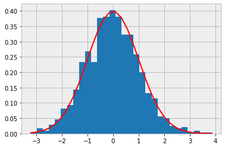

```python
import matplotlib.pyplot as plt
mu = 0
sigma = 1

count, bins, ignored = plt.hist(ser, 30, density=True)
plt.plot(bins, 1/(sigma * np.sqrt(2 * np.pi)) *
               np.exp( - (bins - mu)**2 / (2 * sigma**2) ),
         linewidth=2, color='r')
plt.show()
```

```python
capped_arr = np.clip(ser.to_numpy(), *np.percentile(ser.to_numpy(),[5,95]) )

capped_ser = pd.Series(capped_arr)
capped_ser
```

[output not shown]

```python
# Solution
def cap_outliers(ser, low_perc, high_perc):
    low, high = ser.quantile([low_perc, high_perc])
    print(low_perc, '%ile: ', low, '|', high_perc, '%ile: ', high)
    ser[ser < low] = low
    ser[ser > high] = high
    return(ser)

capped_ser = cap_outliers(ser, .05, .95)
capped_ser
```

```
0.05 %ile:  -1.7232162294574442 | 0.95 %ile:  1.663654730340033
```

```
0     -1.723216
1     -1.723216
2     -1.723216
3     -1.723216
4     -1.723216
         ...
995    1.663655
996    1.663655
997    1.663655
998    1.663655
999    1.663655
Length: 1000, dtype: float64
```

## How to reshape a dataframe to the largest possible square after removing the negative values?

> Reshape df to the largest possible square with negative values removed. Drop the smallest values if need be. The order of the positive numbers in the result should remain the same as the original.

```python
np.random.seed(100)
df = pd.DataFrame(np.random.randint(-20, 50, 100).reshape(10,-1))
df
```

|  | 0 | 1 | 2 | 3 | 4 | 5 | 6 | 7 | 8 | 9 |
| --- | --- | --- | --- | --- | --- | --- | --- | --- | --- | --- |
| 0 | -12 | 4 | 47 | 28 | -10 | 32 | 33 | 46 | -6 | 14 |
| 1 | 4 | -5 | 40 | 38 | -4 | -11 | -18 | 7 | -16 | 11 |
| 2 | -19 | -7 | -16 | 39 | 47 | -13 | 29 | 27 | 45 | 41 |
| 3 | -6 | 35 | -18 | -1 | 43 | 33 | 7 | 36 | 10 | 28 |
| 4 | 27 | 19 | 18 | 24 | -2 | 44 | 36 | 14 | 33 | -3 |
| 5 | -7 | 10 | -3 | 33 | 48 | 30 | 33 | -20 | -7 | 37 |
| 6 | -17 | -17 | -10 | 40 | -17 | 28 | 32 | 23 | 16 | -15 |
| 7 | 18 | 22 | 13 | 38 | 22 | 2 | -20 | 35 | -1 | 33 |
| 8 | 48 | 42 | 30 | 48 | 15 | 3 | -11 | 28 | 1 | 5 |
| 9 | 34 | -14 | 17 | 38 | 19 | 31 | 10 | 46 | 4 | 35 |

```python
# Solution
# Step 1: remove negative values from arr
arr = df[df > 0].values.flatten()
arr_qualified = arr[~np.isnan(arr)]

# Step 2: find side-length of largest possible square
n = int(np.floor(arr_qualified.shape[0]**.5))

# Step 3: Take top n^2 items without changing positions
top_indexes = np.argsort(arr_qualified)[::-1]
output = np.take(arr_qualified, sorted(top_indexes[:n**2])).reshape(n, -1)
print(output)
```

```
[[47. 28. 32. 33. 46. 14. 40. 38.]
 [ 7. 11. 39. 47. 29. 27. 45. 41.]
 [35. 43. 33.  7. 36. 10. 28. 27.]
 [19. 18. 24. 44. 36. 14. 33. 10.]
 [33. 48. 30. 33. 37. 40. 28. 32.]
 [23. 16. 18. 22. 13. 38. 22. 35.]
 [33. 48. 42. 30. 48. 15. 28.  5.]
 [34. 17. 38. 19. 31. 10. 46. 35.]]
```

## **How to swap two rows of a dataframe?

> Swap rows 1 and 2 in df.

```python
df = pd.DataFrame(np.arange(20).reshape(5, -1))
df
```

|  | 0 | 1 | 2 | 3 |
| --- | --- | --- | --- | --- |
| 0 | 0 | 1 | 2 | 3 |
| 1 | 4 | 5 | 6 | 7 |
| 2 | 8 | 9 | 10 | 11 |
| 3 | 12 | 13 | 14 | 15 |
| 4 | 16 | 17 | 18 | 19 |

```python
arr = df.to_numpy()
arr[[0,1]] = arr[[1,0]]

pd.DataFrame(arr)
```

|  | 0 | 1 | 2 | 3 |
| --- | --- | --- | --- | --- |
| 0 | 4 | 5 | 6 | 7 |
| 1 | 0 | 1 | 2 | 3 |
| 2 | 8 | 9 | 10 | 11 |
| 3 | 12 | 13 | 14 | 15 |
| 4 | 16 | 17 | 18 | 19 |

```python
row0 = df.loc[0].copy() # we need copy here, row1 is 0th index
row1 = df.loc[1].copy()

df.loc[0] = row1
df.loc[1] = row0
df
```

|  | 0 | 1 | 2 | 3 |
| --- | --- | --- | --- | --- |
| 0 | 0 | 1 | 2 | 3 |
| 1 | 4 | 5 | 6 | 7 |
| 2 | 8 | 9 | 10 | 11 |
| 3 | 12 | 13 | 14 | 15 |
| 4 | 16 | 17 | 18 | 19 |

```python
# Input
df = pd.DataFrame(np.arange(20).reshape(5, -1))

# Solution
def swap_rows(df, i1, i2):
    a, b = df.iloc[i1, :].copy(), df.iloc[i2, :].copy()
    df.iloc[i1, :], df.iloc[i2, :] = b, a
    return df

print(swap_rows(df, 1, 2))
```

```
    0   1   2   3
0   0   1   2   3
1   8   9  10  11
2   4   5   6   7
3  12  13  14  15
4  16  17  18  19
```

## How to reverse the rows of a dataframe?

Reverse all the rows of dataframe df.

```python
df = pd.DataFrame(np.arange(20).reshape(5, -1))
df
```

|  | 0 | 1 | 2 | 3 |
| --- | --- | --- | --- | --- |
| 0 | 0 | 1 | 2 | 3 |
| 1 | 4 | 5 | 6 | 7 |
| 2 | 8 | 9 | 10 | 11 |
| 3 | 12 | 13 | 14 | 15 |
| 4 | 16 | 17 | 18 | 19 |

```python
df[::-1]
```

|  | 0 | 1 | 2 | 3 |
| --- | --- | --- | --- | --- |
| 4 | 16 | 17 | 18 | 19 |
| 3 | 12 | 13 | 14 | 15 |
| 2 | 8 | 9 | 10 | 11 |
| 1 | 4 | 5 | 6 | 7 |
| 0 | 0 | 1 | 2 | 3 |

## How to create one-hot encodings of a categorical variable (dummy variables)?

> Get one-hot encodings for column 'a' in the dataframe df and append it as columns.

```python
df = pd.DataFrame(np.arange(25).reshape(5,-1), columns=list('abcde'))
df
```

|  | a | b | c | d | e |
| --- | --- | --- | --- | --- | --- |
| 0 | 0 | 1 | 2 | 3 | 4 |
| 1 | 5 | 6 | 7 | 8 | 9 |
| 2 | 10 | 11 | 12 | 13 | 14 |
| 3 | 15 | 16 | 17 | 18 | 19 |
| 4 | 20 | 21 | 22 | 23 | 24 |

```python
pd.get_dummies(df,columns=['a'],drop_first=False)
```

|  | b | c | d | e | a_0 | a_5 | a_10 | a_15 | a_20 |
| --- | --- | --- | --- | --- | --- | --- | --- | --- | --- |
| 0 | 1 | 2 | 3 | 4 | 1 | 0 | 0 | 0 | 0 |
| 1 | 6 | 7 | 8 | 9 | 0 | 1 | 0 | 0 | 0 |
| 2 | 11 | 12 | 13 | 14 | 0 | 0 | 1 | 0 | 0 |
| 3 | 16 | 17 | 18 | 19 | 0 | 0 | 0 | 1 | 0 |
| 4 | 21 | 22 | 23 | 24 | 0 | 0 | 0 | 0 | 1 |

```python
pd.get_dummies(df['a'])
```

|  | 0 | 5 | 10 | 15 | 20 |
| --- | --- | --- | --- | --- | --- |
| 0 | 1 | 0 | 0 | 0 | 0 |
| 1 | 0 | 1 | 0 | 0 | 0 |
| 2 | 0 | 0 | 1 | 0 | 0 |
| 3 | 0 | 0 | 0 | 1 | 0 |
| 4 | 0 | 0 | 0 | 0 | 1 |

```python
pd.concat([pd.get_dummies(df['a']), df.drop('a',axis=1)], axis=1)
```

|  | 0 | 5 | 10 | 15 | 20 | b | c | d | e |
| --- | --- | --- | --- | --- | --- | --- | --- | --- | --- |
| 0 | 1 | 0 | 0 | 0 | 0 | 1 | 2 | 3 | 4 |
| 1 | 0 | 1 | 0 | 0 | 0 | 6 | 7 | 8 | 9 |
| 2 | 0 | 0 | 1 | 0 | 0 | 11 | 12 | 13 | 14 |
| 3 | 0 | 0 | 0 | 1 | 0 | 16 | 17 | 18 | 19 |
| 4 | 0 | 0 | 0 | 0 | 1 | 21 | 22 | 23 | 24 |

## **Which column contains the highest number of row-wise maximum values?

> Obtain the column name with the highest number of row-wise maximum’s in df.

```python
np.random.seed(100)
df = pd.DataFrame(np.random.randint(1,100, 40).reshape(10, -1))
df
```

|  | 0 | 1 | 2 | 3 |
| --- | --- | --- | --- | --- |
| 0 | 9 | 25 | 68 | 88 |
| 1 | 80 | 49 | 11 | 95 |
| 2 | 53 | 99 | 54 | 67 |
| 3 | 99 | 15 | 35 | 25 |
| 4 | 16 | 61 | 59 | 17 |
| 5 | 10 | 94 | 87 | 3 |
| 6 | 28 | 5 | 32 | 2 |
| 7 | 14 | 84 | 5 | 92 |
| 8 | 60 | 68 | 8 | 50 |
| 9 | 48 | 66 | 62 | 15 |

```python
# row wise max
df.max(axis=1)
```

```
0    88
1    95
2    99
3    99
4    61
5    94
6    32
7    92
8    68
9    66
dtype: int64
```

```python
num_max_rows = [(df[col]== df.max(1)).sum() for col in df.columns]
num_max_rows
```

```
[1, 5, 1, 3]
```

```python
np.argmax(np.array(num_max_rows))
```

```
1
```

```python
df1 = df.copy()
df1['row_max'] = df1.max(1)
df1
```

|  | 0 | 1 | 2 | 3 | row_max |
| --- | --- | --- | --- | --- | --- |
| 0 | 9 | 25 | 68 | 88 | 88 |
| 1 | 80 | 49 | 11 | 95 | 95 |
| 2 | 53 | 99 | 54 | 67 | 99 |
| 3 | 99 | 15 | 35 | 25 | 99 |
| 4 | 16 | 61 | 59 | 17 | 61 |
| 5 | 10 | 94 | 87 | 3 | 94 |
| 6 | 28 | 5 | 32 | 2 | 32 |
| 7 | 14 | 84 | 5 | 92 | 92 |
| 8 | 60 | 68 | 8 | 50 | 68 |
| 9 | 48 | 66 | 62 | 15 | 66 |

```python
df1.style.apply(lambda x: ["background: salmon" if  v == x['row_max'] else "" for v in x], axis = 1)
```

|  | 0 | 1 | 2 | 3 | row_max |
| --- | --- | --- | --- | --- | --- |
| 0 | 9 | 25 | 68 | 88 | 88 |
| 1 | 80 | 49 | 11 | 95 | 95 |
| 2 | 53 | 99 | 54 | 67 | 99 |
| 3 | 99 | 15 | 35 | 25 | 99 |
| 4 | 16 | 61 | 59 | 17 | 61 |
| 5 | 10 | 94 | 87 | 3 | 94 |
| 6 | 28 | 5 | 32 | 2 | 32 |
| 7 | 14 | 84 | 5 | 92 | 92 |
| 8 | 60 | 68 | 8 | 50 | 68 |
| 9 | 48 | 66 | 62 | 15 | 66 |

```python
# Solution
print('Column with highest row maxes: ', df.apply(np.argmax, axis=1).value_counts().index[0])
```

```
Column with highest row maxes:  1
```

```python
np.tile(df.max(1).to_numpy(), (df.shape[1],1)).T
```

```
array([[88, 88, 88, 88],
       [95, 95, 95, 95],
       [99, 99, 99, 99],
       [99, 99, 99, 99],
       [61, 61, 61, 61],
       [94, 94, 94, 94],
       [32, 32, 32, 32],
       [92, 92, 92, 92],
       [68, 68, 68, 68],
       [66, 66, 66, 66]])
```

```python
df.to_numpy() == np.tile(df.max(1).to_numpy(), (df.shape[1],1)).T
```

```
array([[False, False, False,  True],
       [False, False, False,  True],
       [False,  True, False, False],
       [ True, False, False, False],
       [False,  True, False, False],
       [False,  True, False, False],
       [False, False,  True, False],
       [False, False, False,  True],
       [False,  True, False, False],
       [False,  True, False, False]])
```

```python
np.sum(df.to_numpy() == np.tile(df.max(1).to_numpy(), (df.shape[1],1)).T, axis=0)
```

```
array([1, 5, 1, 3])
```

```python
np.sum(df.to_numpy() == np.tile(df.max(1).to_numpy(), (df.shape[1],1)).T, axis=0).argmax()
```

```
1
```

## **How to create a new column that contains the row number of nearest column by euclidean distance?

```python
np.random.seed(100)
df = pd.DataFrame(np.random.randint(1,100, 40).reshape(10, -1), columns=list('pqrs'), index=list('abcdefghij'))
df
```

|  | p | q | r | s |
| --- | --- | --- | --- | --- |
| a | 9 | 25 | 68 | 88 |
| b | 80 | 49 | 11 | 95 |
| c | 53 | 99 | 54 | 67 |
| d | 99 | 15 | 35 | 25 |
| e | 16 | 61 | 59 | 17 |
| f | 10 | 94 | 87 | 3 |
| g | 28 | 5 | 32 | 2 |
| h | 14 | 84 | 5 | 92 |
| i | 60 | 68 | 8 | 50 |
| j | 48 | 66 | 62 | 15 |

```python
np.random.seed(100)
df = pd.DataFrame(np.random.randint(1,100, 40).reshape(10, -1), columns=list('pqrs'), index=list('abcdefghij'))

# init outputs
nearest_rows = []
nearest_distance = []

# iterate rows.
for i, row in df.iterrows():
    curr = row
    rest = df.drop(i)
    e_dists = {}  # init dict to store euclidean dists for current row.
    # iterate rest of rows for current row
    for j, contestant in rest.iterrows():
        # compute euclidean dist and update e_dists
        e_dists.update({j: round(np.linalg.norm(curr.values - contestant.values))})
    # update nearest row to current row and the distance value
    nearest_rows.append(max(e_dists, key=e_dists.get))
    nearest_distance.append(max(e_dists.values()))

df['nearest_row'] = nearest_rows
df['dist'] = nearest_distance
df
```

|  | p | q | r | s | nearest_row | dist |
| --- | --- | --- | --- | --- | --- | --- |
| a | 9 | 25 | 68 | 88 | d | 115.0 |
| b | 80 | 49 | 11 | 95 | f | 145.0 |
| c | 53 | 99 | 54 | 67 | g | 119.0 |
| d | 99 | 15 | 35 | 25 | f | 132.0 |
| e | 16 | 61 | 59 | 17 | b | 112.0 |
| f | 10 | 94 | 87 | 3 | b | 145.0 |
| g | 28 | 5 | 32 | 2 | h | 124.0 |
| h | 14 | 84 | 5 | 92 | d | 132.0 |
| i | 60 | 68 | 8 | 50 | f | 108.0 |
| j | 48 | 66 | 62 | 15 | h | 103.0 |

```python
from scipy.spatial.distance import pdist, squareform

np.random.seed(100)
df = pd.DataFrame(np.random.randint(1,100, 40).reshape(10, -1), columns=list('pqrs'), index=list('abcdefghij'))


dist = pdist(df, 'euclidean')

df_dist = pd.DataFrame(squareform(dist),
index=list('abcdefghij'),
columns=list('abcdefghij'))

df_dist
```

|  | a | b | c | d | e | f | g | h | i | j |
| --- | --- | --- | --- | --- | --- | --- | --- | --- | --- | --- |
| a | 0.000000 | 94.419278 | 89.716219 | 115.143389 | 80.417660 | 111.121555 | 97.226540 | 86.550563 | 97.437159 | 92.558090 |
| b | 94.419278 | 0.000000 | 76.563699 | 83.624159 | 112.374374 | 145.481958 | 117.175083 | 75.006666 | 52.867760 | 101.557865 |
| c | 89.716219 | 76.563699 | 0.000000 | 106.287346 | 73.061618 | 84.017855 | 119.037809 | 69.079664 | 58.438001 | 62.305698 |
| d | 115.143389 | 83.624159 | 106.287346 | 0.000000 | 98.208961 | 131.719399 | 75.359140 | 131.814263 | 75.392307 | 77.659513 |
| e | 80.417660 | 112.374374 | 73.061618 | 98.208961 | 0.000000 | 45.880279 | 65.069194 | 95.257546 | 75.332596 | 32.588341 |
| f | 111.121555 | 145.481958 | 84.017855 | 131.719399 | 45.880279 | 0.000000 | 106.164966 | 121.494856 | 107.823931 | 54.744863 |
| g | 97.226540 | 117.175083 | 119.037809 | 75.359140 | 65.069194 | 106.164966 | 0.000000 | 123.555655 | 88.729927 | 72.041655 |
| h | 86.550563 | 75.006666 | 69.079664 | 131.814263 | 95.257546 | 121.494856 | 123.555655 | 0.000000 | 64.381674 | 103.237590 |
| i | 97.437159 | 52.867760 | 58.438001 | 75.392307 | 75.332596 | 107.823931 | 88.729927 | 64.381674 | 0.000000 | 65.490457 |
| j | 92.558090 | 101.557865 | 62.305698 | 77.659513 | 32.588341 | 54.744863 | 72.041655 | 103.237590 | 65.490457 | 0.000000 |

```python
(df
.assign(nearest_row = df_dist.apply(lambda x: x.idxmax(), axis=0))
.assign(dist = df_dist.apply(lambda x: x.max(), axis=0))
)
```

|  | p | q | r | s | nearest_row | dist |
| --- | --- | --- | --- | --- | --- | --- |
| a | 9 | 25 | 68 | 88 | d | 115.143389 |
| b | 80 | 49 | 11 | 95 | f | 145.481958 |
| c | 53 | 99 | 54 | 67 | g | 119.037809 |
| d | 99 | 15 | 35 | 25 | h | 131.814263 |
| e | 16 | 61 | 59 | 17 | b | 112.374374 |
| f | 10 | 94 | 87 | 3 | b | 145.481958 |
| g | 28 | 5 | 32 | 2 | h | 123.555655 |
| h | 14 | 84 | 5 | 92 | d | 131.814263 |
| i | 60 | 68 | 8 | 50 | f | 107.823931 |
| j | 48 | 66 | 62 | 15 | h | 103.237590 |

## **How to know the maximum possible correlation value of each column against other columns?

> Compute maximum possible absolute correlation value of each column against other columns in df.

```python
np.random.seed(100)
df = pd.DataFrame(np.random.randint(1,100, 80).reshape(8, -1), columns=list('pqrstuvwxy'), index=list('abcdefgh'))
df
```

|  | p | q | r | s | t | u | v | w | x | y |
| --- | --- | --- | --- | --- | --- | --- | --- | --- | --- | --- |
| a | 9 | 25 | 68 | 88 | 80 | 49 | 11 | 95 | 53 | 99 |
| b | 54 | 67 | 99 | 15 | 35 | 25 | 16 | 61 | 59 | 17 |
| c | 10 | 94 | 87 | 3 | 28 | 5 | 32 | 2 | 14 | 84 |
| d | 5 | 92 | 60 | 68 | 8 | 50 | 48 | 66 | 62 | 15 |
| e | 56 | 72 | 81 | 3 | 95 | 20 | 99 | 64 | 54 | 28 |
| f | 57 | 31 | 49 | 48 | 40 | 39 | 45 | 19 | 65 | 57 |
| g | 35 | 54 | 75 | 18 | 73 | 14 | 31 | 18 | 54 | 69 |
| h | 51 | 92 | 92 | 84 | 54 | 79 | 1 | 14 | 58 | 77 |

```python
df.corr().abs()
```

|  | p | q | r | s | t | u | v | w | x | y |
| --- | --- | --- | --- | --- | --- | --- | --- | --- | --- | --- |
| p | 1.000000 | 0.141010 | 0.227098 | 0.265108 | 0.324185 | 0.057459 | 0.196782 | 0.228487 | 0.454752 | 0.299886 |
| q | 0.141010 | 1.000000 | 0.511982 | 0.204150 | 0.446381 | 0.028767 | 0.071733 | 0.339051 | 0.374007 | 0.308756 |
| r | 0.227098 | 0.511982 | 1.000000 | 0.354766 | 0.108930 | 0.130976 | 0.272760 | 0.129220 | 0.355986 | 0.031784 |
| s | 0.265108 | 0.204150 | 0.354766 | 1.000000 | 0.086377 | 0.905234 | 0.512726 | 0.303129 | 0.449848 | 0.315986 |
| t | 0.324185 | 0.446381 | 0.108930 | 0.086377 | 1.000000 | 0.085898 | 0.261239 | 0.253490 | 0.111025 | 0.317856 |
| u | 0.057459 | 0.028767 | 0.130976 | 0.905234 | 0.085898 | 1.000000 | 0.428679 | 0.172237 | 0.547130 | 0.113304 |
| v | 0.196782 | 0.071733 | 0.272760 | 0.512726 | 0.261239 | 0.428679 | 1.000000 | 0.144760 | 0.038545 | 0.504748 |
| w | 0.228487 | 0.339051 | 0.129220 | 0.303129 | 0.253490 | 0.172237 | 0.144760 | 1.000000 | 0.394792 | 0.281705 |
| x | 0.454752 | 0.374007 | 0.355986 | 0.449848 | 0.111025 | 0.547130 | 0.038545 | 0.394792 | 1.000000 | 0.441223 |
| y | 0.299886 | 0.308756 | 0.031784 | 0.315986 | 0.317856 | 0.113304 | 0.504748 | 0.281705 | 0.441223 | 1.000000 |

```python
df.corr().abs().apply(lambda x: sorted(x)[-2])
```

```
p    0.454752
q    0.511982
r    0.511982
s    0.905234
t    0.446381
u    0.905234
v    0.512726
w    0.394792
x    0.547130
y    0.504748
dtype: float64
```

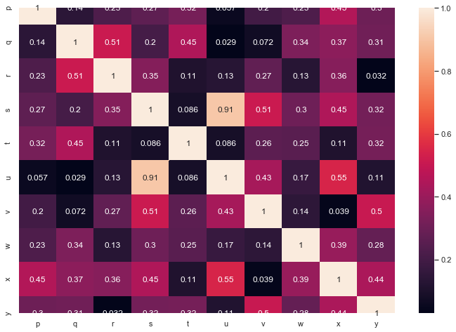

```python
import seaborn as sns
sns.set(color_codes=True)

plt.figure(figsize=(12,8))
sns.heatmap(df.corr().abs(),annot=True)
```

```python
# look at x-axis indices
# exclude diagonal and upper triangle
# for column p, we can see 0.45 is max correlation with column x
```

```python
df.corr().abs().style.background_gradient(cmap='Blues')
```

|  | p | q | r | s | t | u | v | w | x | y |
| --- | --- | --- | --- | --- | --- | --- | --- | --- | --- | --- |
| p | 1 | 0.14101 | 0.227098 | 0.265108 | 0.324185 | 0.0574592 | 0.196782 | 0.228487 | 0.454752 | 0.299886 |
| q | 0.14101 | 1 | 0.511982 | 0.20415 | 0.446381 | 0.0287674 | 0.0717334 | 0.339051 | 0.374007 | 0.308756 |
| r | 0.227098 | 0.511982 | 1 | 0.354766 | 0.10893 | 0.130976 | 0.27276 | 0.12922 | 0.355986 | 0.0317843 |
| s | 0.265108 | 0.20415 | 0.354766 | 1 | 0.0863767 | 0.905234 | 0.512726 | 0.303129 | 0.449848 | 0.315986 |
| t | 0.324185 | 0.446381 | 0.10893 | 0.0863767 | 1 | 0.0858985 | 0.261239 | 0.25349 | 0.111025 | 0.317856 |
| u | 0.0574592 | 0.0287674 | 0.130976 | 0.905234 | 0.0858985 | 1 | 0.428679 | 0.172237 | 0.54713 | 0.113304 |
| v | 0.196782 | 0.0717334 | 0.27276 | 0.512726 | 0.261239 | 0.428679 | 1 | 0.14476 | 0.038545 | 0.504748 |
| w | 0.228487 | 0.339051 | 0.12922 | 0.303129 | 0.25349 | 0.172237 | 0.14476 | 1 | 0.394792 | 0.281705 |
| x | 0.454752 | 0.374007 | 0.355986 | 0.449848 | 0.111025 | 0.54713 | 0.038545 | 0.394792 | 1 | 0.441223 |
| y | 0.299886 | 0.308756 | 0.0317843 | 0.315986 | 0.317856 | 0.113304 | 0.504748 | 0.281705 | 0.441223 | 1 |

## How to create a column containing the minimum by maximum of each row?

> Compute the minimum-by-maximum for every row of df.

```python
np.random.seed(100)
df = pd.DataFrame(np.random.randint(1,100, 80).reshape(8, -1))
df
```

|  | 0 | 1 | 2 | 3 | 4 | 5 | 6 | 7 | 8 | 9 |
| --- | --- | --- | --- | --- | --- | --- | --- | --- | --- | --- |
| 0 | 9 | 25 | 68 | 88 | 80 | 49 | 11 | 95 | 53 | 99 |
| 1 | 54 | 67 | 99 | 15 | 35 | 25 | 16 | 61 | 59 | 17 |
| 2 | 10 | 94 | 87 | 3 | 28 | 5 | 32 | 2 | 14 | 84 |
| 3 | 5 | 92 | 60 | 68 | 8 | 50 | 48 | 66 | 62 | 15 |
| 4 | 56 | 72 | 81 | 3 | 95 | 20 | 99 | 64 | 54 | 28 |
| 5 | 57 | 31 | 49 | 48 | 40 | 39 | 45 | 19 | 65 | 57 |
| 6 | 35 | 54 | 75 | 18 | 73 | 14 | 31 | 18 | 54 | 69 |
| 7 | 51 | 92 | 92 | 84 | 54 | 79 | 1 | 14 | 58 | 77 |

```python
pd.options.display.max_columns = 30
df['row_min'] = df.min(axis=1)
df['row_max'] = df.max(axis=1)
df['min/max'] = df['row_min'] / df['row_max']
df
```

|  | 0 | 1 | 2 | 3 | 4 | 5 | 6 | 7 | 8 | 9 | row_min | row_max | min/max |
| --- | --- | --- | --- | --- | --- | --- | --- | --- | --- | --- | --- | --- | --- |
| 0 | 9 | 25 | 68 | 88 | 80 | 49 | 11 | 95 | 53 | 99 | 9 | 99 | 0.090909 |
| 1 | 54 | 67 | 99 | 15 | 35 | 25 | 16 | 61 | 59 | 17 | 15 | 99 | 0.151515 |
| 2 | 10 | 94 | 87 | 3 | 28 | 5 | 32 | 2 | 14 | 84 | 2 | 94 | 0.021277 |
| 3 | 5 | 92 | 60 | 68 | 8 | 50 | 48 | 66 | 62 | 15 | 5 | 92 | 0.054348 |
| 4 | 56 | 72 | 81 | 3 | 95 | 20 | 99 | 64 | 54 | 28 | 3 | 99 | 0.030303 |
| 5 | 57 | 31 | 49 | 48 | 40 | 39 | 45 | 19 | 65 | 57 | 19 | 65 | 0.292308 |
| 6 | 35 | 54 | 75 | 18 | 73 | 14 | 31 | 18 | 54 | 69 | 14 | 75 | 0.186667 |
| 7 | 51 | 92 | 92 | 84 | 54 | 79 | 1 | 14 | 58 | 77 | 1 | 92 | 0.010870 |

```python
min_by_max = np.min(df, axis=1)/np.max(df, axis=1)
min_by_max
```

```
0    0.000918
1    0.001530
2    0.000226
3    0.000591
4    0.000306
5    0.004497
6    0.002489
7    0.000118
dtype: float64
```

## How to create a column that contains the penultimate value in each row?

> Create a new column 'penultimate' which has the second largest value of each row of df.

Ref: https://stackoverflow.com/questions/39066260/get-first-and-second-highest-values-in-pandas-columns

```python
np.random.seed(100)
df = pd.DataFrame(np.random.randint(1,100, 80).reshape(8, -1))
df
```

|  | 0 | 1 | 2 | 3 | 4 | 5 | 6 | 7 | 8 | 9 |
| --- | --- | --- | --- | --- | --- | --- | --- | --- | --- | --- |
| 0 | 9 | 25 | 68 | 88 | 80 | 49 | 11 | 95 | 53 | 99 |
| 1 | 54 | 67 | 99 | 15 | 35 | 25 | 16 | 61 | 59 | 17 |
| 2 | 10 | 94 | 87 | 3 | 28 | 5 | 32 | 2 | 14 | 84 |
| 3 | 5 | 92 | 60 | 68 | 8 | 50 | 48 | 66 | 62 | 15 |
| 4 | 56 | 72 | 81 | 3 | 95 | 20 | 99 | 64 | 54 | 28 |
| 5 | 57 | 31 | 49 | 48 | 40 | 39 | 45 | 19 | 65 | 57 |
| 6 | 35 | 54 | 75 | 18 | 73 | 14 | 31 | 18 | 54 | 69 |
| 7 | 51 | 92 | 92 | 84 | 54 | 79 | 1 | 14 | 58 | 77 |

```python
df.apply(lambda x: sorted(x)[-2],axis=1)
```

```
0    95
1    67
2    87
3    68
4    95
5    57
6    73
7    92
dtype: int64
```

```python
df.apply(lambda x: x.nlargest(2).to_numpy()[-1],axis=1)
```

```
0    95
1    67
2    87
3    68
4    95
5    57
6    73
7    92
dtype: int64
```

```python
%%timeit
df.apply(lambda x: sorted(x)[-2],axis=1)
```

```
775 µs ± 83.7 µs per loop (mean ± std. dev. of 7 runs, 1000 loops each)
```

```python
%%timeit
df.apply(lambda x: x.nlargest(2).to_numpy()[-1],axis=1)
```

```
2.09 ms ± 52.1 µs per loop (mean ± std. dev. of 7 runs, 100 loops each)
```

```python
%%timeit
pd.DataFrame(np.sort(df.values)[:,-2:], columns=['2nd-largest','largest'])
```

```
146 µs ± 2.7 µs per loop (mean ± std. dev. of 7 runs, 10000 loops each)
```

```python
%%timeit
a = df.values
top2 = a[np.arange(len(df))[:,None],np.argpartition(-a,np.arange(2),axis=1)[:,:2]]
df1 = pd.DataFrame(top2, columns=['largest','2nd-largest'])
df1
```

```
159 µs ± 435 ns per loop (mean ± std. dev. of 7 runs, 10000 loops each)
```

## How to normalize all columns in a dataframe?

```python
np.random.seed(100)
df = pd.DataFrame(np.random.randint(1,100, 80).reshape(8, -1))
df
```

|  | 0 | 1 | 2 | 3 | 4 | 5 | 6 | 7 | 8 | 9 |
| --- | --- | --- | --- | --- | --- | --- | --- | --- | --- | --- |
| 0 | 9 | 25 | 68 | 88 | 80 | 49 | 11 | 95 | 53 | 99 |
| 1 | 54 | 67 | 99 | 15 | 35 | 25 | 16 | 61 | 59 | 17 |
| 2 | 10 | 94 | 87 | 3 | 28 | 5 | 32 | 2 | 14 | 84 |
| 3 | 5 | 92 | 60 | 68 | 8 | 50 | 48 | 66 | 62 | 15 |
| 4 | 56 | 72 | 81 | 3 | 95 | 20 | 99 | 64 | 54 | 28 |
| 5 | 57 | 31 | 49 | 48 | 40 | 39 | 45 | 19 | 65 | 57 |
| 6 | 35 | 54 | 75 | 18 | 73 | 14 | 31 | 18 | 54 | 69 |
| 7 | 51 | 92 | 92 | 84 | 54 | 79 | 1 | 14 | 58 | 77 |

```python
df.apply(lambda x:   (x - x.mean()) / x.std()  , axis=1)
```

|  | 0 | 1 | 2 | 3 | 4 | 5 | 6 | 7 | 8 | 9 |
| --- | --- | --- | --- | --- | --- | --- | --- | --- | --- | --- |
| 0 | -1.436911 | -0.964825 | 0.303905 | 0.894012 | 0.657969 | -0.256697 | -1.377900 | 1.100550 | -0.138675 | 1.218571 |
| 1 | 0.330887 | 0.798444 | 1.949354 | -1.071785 | -0.352466 | -0.712126 | -1.035819 | 0.582648 | 0.510716 | -0.999853 |
| 2 | -0.689072 | 1.545756 | 1.359520 | -0.875308 | -0.210180 | -0.822097 | -0.103760 | -0.901913 | -0.582652 | 1.279705 |
| 3 | -1.465033 | 1.541049 | 0.435364 | 0.711785 | -1.361375 | 0.089837 | 0.020732 | 0.642680 | 0.504469 | -1.119507 |
| 4 | -0.037546 | 0.463063 | 0.744656 | -1.695812 | 1.182688 | -1.163915 | 1.307840 | 0.212759 | -0.100122 | -0.913611 |
| 5 | 0.887335 | -1.035224 | 0.295778 | 0.221834 | -0.369723 | -0.443667 | 0.000000 | -1.922559 | 1.478892 | 0.887335 |
| 6 | -0.381198 | 0.414710 | 1.294397 | -1.093326 | 1.210618 | -1.260885 | -0.548757 | -1.093326 | 0.414710 | 1.043058 |
| 7 | -0.291065 | 1.006074 | 1.006074 | 0.752974 | -0.196153 | 0.594786 | -1.872943 | -1.461655 | -0.069603 | 0.531511 |

```python
df.apply(lambda x:  ( (x - x.min()) / ( (x.max() - x.min()))) , axis=1)
```

|  | 0 | 1 | 2 | 3 | 4 | 5 | 6 | 7 | 8 | 9 |
| --- | --- | --- | --- | --- | --- | --- | --- | --- | --- | --- |
| 0 | 0.000000 | 0.177778 | 0.655556 | 0.877778 | 0.788889 | 0.444444 | 0.022222 | 0.955556 | 0.488889 | 1.000000 |
| 1 | 0.464286 | 0.619048 | 1.000000 | 0.000000 | 0.238095 | 0.119048 | 0.011905 | 0.547619 | 0.523810 | 0.023810 |
| 2 | 0.086957 | 1.000000 | 0.923913 | 0.010870 | 0.282609 | 0.032609 | 0.326087 | 0.000000 | 0.130435 | 0.891304 |
| 3 | 0.000000 | 1.000000 | 0.632184 | 0.724138 | 0.034483 | 0.517241 | 0.494253 | 0.701149 | 0.655172 | 0.114943 |
| 4 | 0.552083 | 0.718750 | 0.812500 | 0.000000 | 0.958333 | 0.177083 | 1.000000 | 0.635417 | 0.531250 | 0.260417 |
| 5 | 0.826087 | 0.260870 | 0.652174 | 0.630435 | 0.456522 | 0.434783 | 0.565217 | 0.000000 | 1.000000 | 0.826087 |
| 6 | 0.344262 | 0.655738 | 1.000000 | 0.065574 | 0.967213 | 0.000000 | 0.278689 | 0.065574 | 0.655738 | 0.901639 |
| 7 | 0.549451 | 1.000000 | 1.000000 | 0.912088 | 0.582418 | 0.857143 | 0.000000 | 0.142857 | 0.626374 | 0.835165 |

## How to compute the correlation of each row with the suceeding row?

> Compute the correlation of each row of df with its succeeding row.

```python
np.random.seed(100)

# Input
df = pd.DataFrame(np.random.randint(1,100, 80).reshape(8, -1))

# Solution
[df.iloc[i].corr(df.iloc[i+1]).round(2) for i in range(df.shape[0])[:-1]]
```

```
[-0.1, 0.36, 0.14, -0.08, -0.22, 0.35, 0.35]
```

## How to replace both the diagonals of dataframe with 0?

```python
np.random.seed(100)
df = pd.DataFrame(np.random.randint(1,100, 100).reshape(10, -1))
df
```

|  | 0 | 1 | 2 | 3 | 4 | 5 | 6 | 7 | 8 | 9 |
| --- | --- | --- | --- | --- | --- | --- | --- | --- | --- | --- |
| 0 | 9 | 25 | 68 | 88 | 80 | 49 | 11 | 95 | 53 | 99 |
| 1 | 54 | 67 | 99 | 15 | 35 | 25 | 16 | 61 | 59 | 17 |
| 2 | 10 | 94 | 87 | 3 | 28 | 5 | 32 | 2 | 14 | 84 |
| 3 | 5 | 92 | 60 | 68 | 8 | 50 | 48 | 66 | 62 | 15 |
| 4 | 56 | 72 | 81 | 3 | 95 | 20 | 99 | 64 | 54 | 28 |
| 5 | 57 | 31 | 49 | 48 | 40 | 39 | 45 | 19 | 65 | 57 |
| 6 | 35 | 54 | 75 | 18 | 73 | 14 | 31 | 18 | 54 | 69 |
| 7 | 51 | 92 | 92 | 84 | 54 | 79 | 1 | 14 | 58 | 77 |
| 8 | 4 | 71 | 4 | 85 | 80 | 11 | 88 | 61 | 4 | 49 |
| 9 | 53 | 44 | 37 | 6 | 72 | 39 | 87 | 95 | 99 | 43 |

```python
a = df.to_numpy()
np.fill_diagonal(a,0)

a = np.rot90(a)
np.fill_diagonal(a,0)

df = pd.DataFrame(a)
df.style.apply(lambda x: ["background: salmon" if  v == 0 else "" for v in x], axis = 1)
```

|  | 0 | 1 | 2 | 3 | 4 | 5 | 6 | 7 | 8 | 9 |
| --- | --- | --- | --- | --- | --- | --- | --- | --- | --- | --- |
| 0 | 0 | 99 | 95 | 87 | 39 | 72 | 6 | 37 | 44 | 0 |
| 1 | 49 | 0 | 61 | 88 | 11 | 80 | 85 | 4 | 0 | 4 |
| 2 | 77 | 58 | 0 | 1 | 79 | 54 | 84 | 0 | 92 | 51 |
| 3 | 69 | 54 | 18 | 0 | 14 | 73 | 0 | 75 | 54 | 35 |
| 4 | 57 | 65 | 19 | 45 | 0 | 0 | 48 | 49 | 31 | 57 |
| 5 | 28 | 54 | 64 | 99 | 0 | 0 | 3 | 81 | 72 | 56 |
| 6 | 15 | 62 | 66 | 0 | 50 | 8 | 0 | 60 | 92 | 5 |
| 7 | 84 | 14 | 0 | 32 | 5 | 28 | 3 | 0 | 94 | 10 |
| 8 | 17 | 0 | 61 | 16 | 25 | 35 | 15 | 99 | 0 | 54 |
| 9 | 0 | 53 | 95 | 11 | 49 | 80 | 88 | 68 | 25 | 0 |

```python
import itertools
from itertools import chain

np.random.seed(100)
df = pd.DataFrame(np.random.randint(1,100, 100).reshape(10, -1))


for x, y in chain.from_iterable(
    [zip(range(10), range(10)),zip(range(10), range(9, 0, -1))]):
    df.iat[x, y] = 0

# bottom left needs to be made 0
print(df.iloc[9,0])
df.iloc[len(df)-1, 0] = 0

df.style.apply(lambda x: ["background: salmon" if  v == 0 else "" for v in x], axis = 1)
```

```
53
```

|  | 0 | 1 | 2 | 3 | 4 | 5 | 6 | 7 | 8 | 9 |
| --- | --- | --- | --- | --- | --- | --- | --- | --- | --- | --- |
| 0 | 0 | 25 | 68 | 88 | 80 | 49 | 11 | 95 | 53 | 0 |
| 1 | 54 | 0 | 99 | 15 | 35 | 25 | 16 | 61 | 0 | 17 |
| 2 | 10 | 94 | 0 | 3 | 28 | 5 | 32 | 0 | 14 | 84 |
| 3 | 5 | 92 | 60 | 0 | 8 | 50 | 0 | 66 | 62 | 15 |
| 4 | 56 | 72 | 81 | 3 | 0 | 0 | 99 | 64 | 54 | 28 |
| 5 | 57 | 31 | 49 | 48 | 0 | 0 | 45 | 19 | 65 | 57 |
| 6 | 35 | 54 | 75 | 0 | 73 | 14 | 0 | 18 | 54 | 69 |
| 7 | 51 | 92 | 0 | 84 | 54 | 79 | 1 | 0 | 58 | 77 |
| 8 | 4 | 0 | 4 | 85 | 80 | 11 | 88 | 61 | 0 | 49 |
| 9 | 0 | 44 | 37 | 6 | 72 | 39 | 87 | 95 | 99 | 0 |

```python
np.random.seed(100)

# Input
df = pd.DataFrame(np.random.randint(1,100, 100).reshape(10, -1))

# Solution
for i in range(df.shape[0]):
    df.iat[i, i] = 0
    df.iat[df.shape[0]-i-1, i] = 0

df.style.apply(lambda x: ["background: salmon" if  v == 0 else "" for v in x], axis = 1)
```

|  | 0 | 1 | 2 | 3 | 4 | 5 | 6 | 7 | 8 | 9 |
| --- | --- | --- | --- | --- | --- | --- | --- | --- | --- | --- |
| 0 | 0 | 25 | 68 | 88 | 80 | 49 | 11 | 95 | 53 | 0 |
| 1 | 54 | 0 | 99 | 15 | 35 | 25 | 16 | 61 | 0 | 17 |
| 2 | 10 | 94 | 0 | 3 | 28 | 5 | 32 | 0 | 14 | 84 |
| 3 | 5 | 92 | 60 | 0 | 8 | 50 | 0 | 66 | 62 | 15 |
| 4 | 56 | 72 | 81 | 3 | 0 | 0 | 99 | 64 | 54 | 28 |
| 5 | 57 | 31 | 49 | 48 | 0 | 0 | 45 | 19 | 65 | 57 |
| 6 | 35 | 54 | 75 | 0 | 73 | 14 | 0 | 18 | 54 | 69 |
| 7 | 51 | 92 | 0 | 84 | 54 | 79 | 1 | 0 | 58 | 77 |
| 8 | 4 | 0 | 4 | 85 | 80 | 11 | 88 | 61 | 0 | 49 |
| 9 | 0 | 44 | 37 | 6 | 72 | 39 | 87 | 95 | 99 | 0 |

## How to get the particular group of a groupby dataframe by key?

> This is a question related to understanding of grouped dataframe. From df_grouped, get the group belonging to 'apple' as a dataframe.

```python
df = pd.DataFrame({'col1': ['apple', 'banana', 'orange'] * 3,
                   'col2': np.random.rand(9),
                   'col3': np.random.randint(0, 15, 9)})

df_grouped = df.groupby(['col1'])
```

```python
# Solution 1
df_grouped.get_group('apple')
```

|  | col1 | col2 | col3 |
| --- | --- | --- | --- |
| 0 | apple | 0.570216 | 14 |
| 3 | apple | 0.217066 | 3 |
| 6 | apple | 0.982630 | 9 |

```python
# Solution 2
for i, dff in df_grouped:
    if i == 'apple':
        display(dff)
```

|  | col1 | col2 | col3 |
| --- | --- | --- | --- |
| 0 | apple | 0.570216 | 14 |
| 3 | apple | 0.217066 | 3 |
| 6 | apple | 0.982630 | 9 |

## How to get the nth largest value of a column when grouped by another column?

> In df, find the second largest value of 'taste' for 'banana'

```python
np.random.seed(100)
df = pd.DataFrame({'fruit': ['apple', 'banana', 'orange'] * 3,
                   'taste': np.random.rand(9),
                   'price': np.random.randint(0, 15, 9)})
df
```

|  | fruit | taste | price |
| --- | --- | --- | --- |
| 0 | apple | 0.543405 | 8 |
| 1 | banana | 0.278369 | 4 |
| 2 | orange | 0.424518 | 11 |
| 3 | apple | 0.844776 | 12 |
| 4 | banana | 0.004719 | 10 |
| 5 | orange | 0.121569 | 0 |
| 6 | apple | 0.670749 | 11 |
| 7 | banana | 0.825853 | 9 |
| 8 | orange | 0.136707 | 13 |

```python
df[df.fruit == 'banana'].nlargest(2,'taste')
```

|  | fruit | taste | price |
| --- | --- | --- | --- |
| 7 | banana | 0.825853 | 9 |
| 1 | banana | 0.278369 | 4 |

```python
df[df.fruit == 'banana'].nlargest(2,'taste')['taste'].to_numpy()[-1]
```

```
0.27836938509379616
```

```python
np.random.seed(100)
df = pd.DataFrame({'fruit': ['apple', 'banana', 'orange'] * 3,
                   'taste': np.random.rand(9),
                   'price': np.random.randint(0, 15, 9)})

# Solution
df_grpd = df['taste'].groupby(df.fruit)
df_grpd.get_group('banana').sort_values().iloc[-2]
```

```
0.27836938509379616
```

## How to compute grouped mean on pandas dataframe and keep the grouped column as another column (not index)?

> In df, Compute the mean price of every fruit, while keeping the fruit as another column instead of an index.

```python
np.random.seed(100)
df = pd.DataFrame({'fruit': ['apple', 'banana', 'orange'] * 3,
                   'rating': np.random.rand(9),
                   'price': np.random.randint(0, 15, 9)})

df
```

|  | fruit | rating | price |
| --- | --- | --- | --- |
| 0 | apple | 0.543405 | 8 |
| 1 | banana | 0.278369 | 4 |
| 2 | orange | 0.424518 | 11 |
| 3 | apple | 0.844776 | 12 |
| 4 | banana | 0.004719 | 10 |
| 5 | orange | 0.121569 | 0 |
| 6 | apple | 0.670749 | 11 |
| 7 | banana | 0.825853 | 9 |
| 8 | orange | 0.136707 | 13 |

```python
df['mean_fruit_price'] = df.groupby('fruit')['price'].transform('mean')
df
```

|  | fruit | rating | price | mean_fruit_price |
| --- | --- | --- | --- | --- |
| 0 | apple | 0.543405 | 8 | 10.333333 |
| 1 | banana | 0.278369 | 4 | 7.666667 |
| 2 | orange | 0.424518 | 11 | 8.000000 |
| 3 | apple | 0.844776 | 12 | 10.333333 |
| 4 | banana | 0.004719 | 10 | 7.666667 |
| 5 | orange | 0.121569 | 0 | 8.000000 |
| 6 | apple | 0.670749 | 11 | 10.333333 |
| 7 | banana | 0.825853 | 9 | 7.666667 |
| 8 | orange | 0.136707 | 13 | 8.000000 |

```python
df.groupby('fruit')['price'].mean().reset_index()
```

|  | fruit | price |
| --- | --- | --- |
| 0 | apple | 10.333333 |
| 1 | banana | 7.666667 |
| 2 | orange | 8.000000 |

## How to join two dataframes by 2 columns so they have only the common rows?

> Join dataframes df1 and df2 by ‘fruit-pazham’ and ‘weight-kilo’.

```python
np.random.seed(100)
df1 = pd.DataFrame({'fruit': ['apple', 'banana', 'orange'] * 3,
                    'weight': ['high', 'medium', 'low'] * 3,
                    'price': np.random.randint(0, 15, 9)})

df2 = pd.DataFrame({'pazham': ['apple', 'orange', 'pine'] * 2,
                    'kilo': ['high', 'low'] * 3,
                    'price': np.random.randint(0, 15, 6)})

display(df1)
df2
```

|  | fruit | weight | price |
| --- | --- | --- | --- |
| 0 | apple | high | 8 |
| 1 | banana | medium | 8 |
| 2 | orange | low | 3 |
| 3 | apple | high | 7 |
| 4 | banana | medium | 7 |
| 5 | orange | low | 0 |
| 6 | apple | high | 10 |
| 7 | banana | medium | 14 |
| 8 | orange | low | 4 |

|  | pazham | kilo | price |
| --- | --- | --- | --- |
| 0 | apple | high | 2 |
| 1 | orange | low | 5 |
| 2 | pine | high | 2 |
| 3 | apple | low | 2 |
| 4 | orange | high | 14 |
| 5 | pine | low | 2 |

```python
df1.merge(df2, left_on=['fruit','weight'], right_on=['pazham','kilo'])
```

|  | fruit | weight | price_x | pazham | kilo | price_y |
| --- | --- | --- | --- | --- | --- | --- |
| 0 | apple | high | 8 | apple | high | 2 |
| 1 | apple | high | 7 | apple | high | 2 |
| 2 | apple | high | 10 | apple | high | 2 |
| 3 | orange | low | 3 | orange | low | 5 |
| 4 | orange | low | 0 | orange | low | 5 |
| 5 | orange | low | 4 | orange | low | 5 |

```python
# Solution
pd.merge(df1, df2, how='inner', left_on=['fruit', 'weight'], right_on=['pazham', 'kilo'], suffixes=['_left', '_right'])
```

|  | fruit | weight | price_left | pazham | kilo | price_right |
| --- | --- | --- | --- | --- | --- | --- |
| 0 | apple | high | 8 | apple | high | 2 |
| 1 | apple | high | 7 | apple | high | 2 |
| 2 | apple | high | 10 | apple | high | 2 |
| 3 | orange | low | 3 | orange | low | 5 |
| 4 | orange | low | 0 | orange | low | 5 |
| 5 | orange | low | 4 | orange | low | 5 |

## **How to remove rows from a dataframe that are present in another dataframe?

> From df1, remove the rows that are present in df2. All three columns must be the same.

```python
df1 = pd.DataFrame({'fruit': ['apple', 'orange', 'banana'] * 3,
                    'weight': ['high', 'medium', 'low'] * 3,
                    'price': np.arange(9)})

df2 = pd.DataFrame({'fruit': ['apple', 'orange', 'pine'] * 2,
                    'weight': ['high', 'medium'] * 3,
                    'price': np.arange(6)})

display(df1)
df2
```

|  | fruit | weight | price |
| --- | --- | --- | --- |
| 0 | apple | high | 0 |
| 1 | orange | medium | 1 |
| 2 | banana | low | 2 |
| 3 | apple | high | 3 |
| 4 | orange | medium | 4 |
| 5 | banana | low | 5 |
| 6 | apple | high | 6 |
| 7 | orange | medium | 7 |
| 8 | banana | low | 8 |

|  | fruit | weight | price |
| --- | --- | --- | --- |
| 0 | apple | high | 0 |
| 1 | orange | medium | 1 |
| 2 | pine | high | 2 |
| 3 | apple | medium | 3 |
| 4 | orange | high | 4 |
| 5 | pine | medium | 5 |

```python
df1[~df1.isin(df2).all(1)]
```

|  | fruit | weight | price |
| --- | --- | --- | --- |
| 2 | banana | low | 2 |
| 3 | apple | high | 3 |
| 4 | orange | medium | 4 |
| 5 | banana | low | 5 |
| 6 | apple | high | 6 |
| 7 | orange | medium | 7 |
| 8 | banana | low | 8 |

## How to get the positions where values of two columns match?

```python
np.random.seed(100)
df = pd.DataFrame({'fruit1': np.random.choice(['apple', 'orange', 'banana'], 10),
                    'fruit2': np.random.choice(['apple', 'orange', 'banana'], 10)})

df
```

|  | fruit1 | fruit2 |
| --- | --- | --- |
| 0 | apple | banana |
| 1 | apple | banana |
| 2 | apple | orange |
| 3 | banana | apple |
| 4 | banana | apple |
| 5 | apple | apple |
| 6 | banana | apple |
| 7 | orange | banana |
| 8 | banana | apple |
| 9 | banana | orange |

```python
np.where(df.fruit1 == df.fruit2)
```

```
(array([5]),)
```

## How to create lags and leads of a column in a dataframe?

> Create two new columns in df, one of which is a lag1 (shift column a down by 1 row) of column ‘a’ and the other is a lead1 (shift column b up by 1 row).

```python
np.random.seed(100)
df = pd.DataFrame(np.random.randint(1, 100, 20).reshape(-1, 4),
                  columns = list('abcd'))
df
```

|  | a | b | c | d |
| --- | --- | --- | --- | --- |
| 0 | 9 | 25 | 68 | 88 |
| 1 | 80 | 49 | 11 | 95 |
| 2 | 53 | 99 | 54 | 67 |
| 3 | 99 | 15 | 35 | 25 |
| 4 | 16 | 61 | 59 | 17 |

```python
df['a_lag1'] = df['a'].shift(1)
df['a_lead1'] = df['a'].shift(-1)
df
```

|  | a | b | c | d | a_lag1 | a_lead1 |
| --- | --- | --- | --- | --- | --- | --- |
| 0 | 9 | 25 | 68 | 88 | NaN | 80.0 |
| 1 | 80 | 49 | 11 | 95 | 9.0 | 53.0 |
| 2 | 53 | 99 | 54 | 67 | 80.0 | 99.0 |
| 3 | 99 | 15 | 35 | 25 | 53.0 | 16.0 |
| 4 | 16 | 61 | 59 | 17 | 99.0 | NaN |

## How to get the frequency of unique values in the entire dataframe?

```python
np.random.seed(100)
df = pd.DataFrame(np.random.randint(1, 10, 20).reshape(-1, 4), columns = list('abcd'))
df
```

|  | a | b | c | d |
| --- | --- | --- | --- | --- |
| 0 | 9 | 9 | 4 | 8 |
| 1 | 8 | 1 | 5 | 3 |
| 2 | 6 | 3 | 3 | 3 |
| 3 | 2 | 1 | 9 | 5 |
| 4 | 1 | 7 | 3 | 5 |

```python
Counter(df.to_numpy().ravel())
```

```
Counter({9: 3, 4: 1, 8: 2, 1: 3, 5: 3, 3: 5, 6: 1, 2: 1, 7: 1})
```

```python
u,c = np.unique(df.to_numpy().ravel(), return_counts=True)

np.c_[u,c]
```

```
array([[1, 3],
       [2, 1],
       [3, 5],
       [4, 1],
       [5, 3],
       [6, 1],
       [7, 1],
       [8, 2],
       [9, 3]])
```

```python
pd.Series(df.to_numpy().ravel()).value_counts()
```

```
3    5
9    3
5    3
1    3
8    2
7    1
6    1
4    1
2    1
dtype: int64
```

```python
pd.value_counts(df.to_numpy().ravel())
```

```
3    5
9    3
5    3
1    3
8    2
7    1
6    1
4    1
2    1
dtype: int64
```

## How to split a text column into two separate columns?

> Split the string column in df to form a dataframe with 3 columns as shown.

```python
df = pd.DataFrame(["STD, City    State",
"33, Kolkata    West Bengal",
"44, Chennai    Tamil Nadu",
"40, Hyderabad    Telengana",
"80, Bangalore    Karnataka"], columns=['row'])
df
```

|  | row |
| --- | --- |
| 0 | STD, City State |
| 1 | 33, Kolkata West Bengal |
| 2 | 44, Chennai Tamil Nadu |
| 3 | 40, Hyderabad Telengana |
| 4 | 80, Bangalore Karnataka |

```python
columns = df.iloc[0].str.replace('\s\s+',',').str.split(',').values
df.row.iloc[1:].str\
.replace('\s\s+',',')\
.str.split(',',expand=True)\
.rename(columns=lambda x: columns[0][x])
```

|  | STD | City | State |
| --- | --- | --- | --- |
| 1 | 33 | Kolkata | West Bengal |
| 2 | 44 | Chennai | Tamil Nadu |
| 3 | 40 | Hyderabad | Telengana |
| 4 | 80 | Bangalore | Karnataka |

```python
# Input
df = pd.DataFrame(["STD, City    State",
"33, Kolkata    West Bengal",
"44, Chennai    Tamil Nadu",
"40, Hyderabad    Telengana",
"80, Bangalore    Karnataka"], columns=['row'])

# Solution
df_out = df.row.str.split(',|\t', expand=True)

# Make first row as header
new_header = df_out.iloc[0]
df_out = df_out[1:]
df_out.columns = new_header
print(df_out)
```

```
0 STD            City    State
1  33   Kolkata    West Bengal
2  44    Chennai    Tamil Nadu
3  40   Hyderabad    Telengana
4  80   Bangalore    Karnataka
```

```python
df.row.str.split(',|\t', expand=True)
```

|  | 0 | 1 |
| --- | --- | --- |
| 0 | STD | City State |
| 1 | 33 | Kolkata West Bengal |
| 2 | 44 | Chennai Tamil Nadu |
| 3 | 40 | Hyderabad Telengana |
| 4 | 80 | Bangalore Karnataka |

```python
(df["row"].iloc[1:]
.str.replace(",", "")
.str.split(expand=True, n=2)
.rename(columns= dict(zip(range(3),
df.iloc[0,0].replace(",", "").split()))))
```

|  | STD | City | State |
| --- | --- | --- | --- |
| 1 | 33 | Kolkata | West Bengal |
| 2 | 44 | Chennai | Tamil Nadu |
| 3 | 40 | Hyderabad | Telengana |
| 4 | 80 | Bangalore | Karnataka |